# 第五章： 专题 1： 点数据分析

章节作者：刘贇喆 | 华东师范大学 社会发展学院

更新时间：2026-10-20

章节概述

本章聚焦空间数据中的点要素 （Point Data），以专题研究为主线，结合真实的多源城市数据展开分析。

专题研究 1 以曼哈顿 Airbnb 房源数据为例，讨论价格的空间异质性与集聚特征；专题研究 2 以上海六区的微博地理坐标点与公共交通 POI为例，识别记录高密度区并比较设施邻近性。

方法层面，本章主要涉及六边形聚合、空间自相关 （Moran’s I / LISA）、核密度估计 （KDE）、AOI 提取，以及在章节练习中引入的DBSCAN聚类，用于理解点模式的空间结构。

# **本章学习内容**

## **学习导航**

**本章学习内容**

欢迎开始 **第 5 章** 的学习。请点击 **下方导航卡** 进入相应小节：

**阅读提示**：通过返回主页或主页按钮，可回到本章学习导航。

**© 华东师范大学 社会发展学院 人口研究所** | [**DAWN 研究组**](https://dawn-ecnu.github.io) | yzliu@soci.ecnu.edu.cn

课程负责人：刘贇喆 本章作者：刘贇喆 | 敖漪宇

最后更新：2026年10月20日 构建环境：R version 4.6.1 (2026-06-24 ucrt)

[CC BY-NC-SA 4.0](https://creativecommons.org/licenses/by-nc-sa/4.0/deed.zh) 回到顶部

## **1.0 空间点数据**

### **1.0 空间点数据概论**

基本概念

第四章介绍了 `sf` 矢量表：每行是一条要素记录，`geometry` 列保存几何，其余列保存属性。本章关注其中的**点记录**。点的位置由坐标和坐标参考系（CRS）共同确定。

**坐标表示位置，其他字段说明对象或事件。** 同一坐标可能对应几家店，也可能对应同一地点在不同时刻的多次签到。坐标因此不能充当记录的唯一编号；一条记录还可能包含地点名称、事件类型、时间和数据来源。

**读点图前，先辨认观察单位**

- **地点**：一家店、一座车站或一个设施入口。
- **事件**：某地某时的一次投诉、事故或签到。
- **移动位置**：一条轨迹中的某个采样点，或一次行程的起点、终点。

点可以代表路灯、居民小区或城市。点位可能来自设备定位或地址地理编码（将地址转换为坐标）。坐标精度和覆盖范围取决于数据的采集方式。

从真实记录读点

下面选取纽约中城六座 Citi Bike 站点，将同一批记录放在表和地图中。字母 A—F 仅用于两边对照；每行对应一座站点。`capacity` 是站点的车位容量，不代表当时可借出的自行车数量。

六座 Citi Bike 站点的属性与几何

| 记录 | 站点名称 | 车位 | `geometry`（便于阅读的表示） |
| --- | --- | --- | --- |
| A | W 35 St & 8 Ave | 45 | `POINT (-73.992805 40.752762)` |
| B | E 40 St & 5 Ave | 93 | `POINT (-73.981632 40.752062)` |
| C | W 42 St & 8 Ave | 41 | `POINT (-73.990985 40.757570)` |
| D | W 44 St & 5 Ave | 68 | `POINT (-73.980144 40.755003)` |
| E | W 49 St & 8 Ave | 67 | `POINT (-73.987882 40.762272)` |
| F | W 51 St & 6 Ave | 81 | `POINT (-73.980420 40.760660)` |

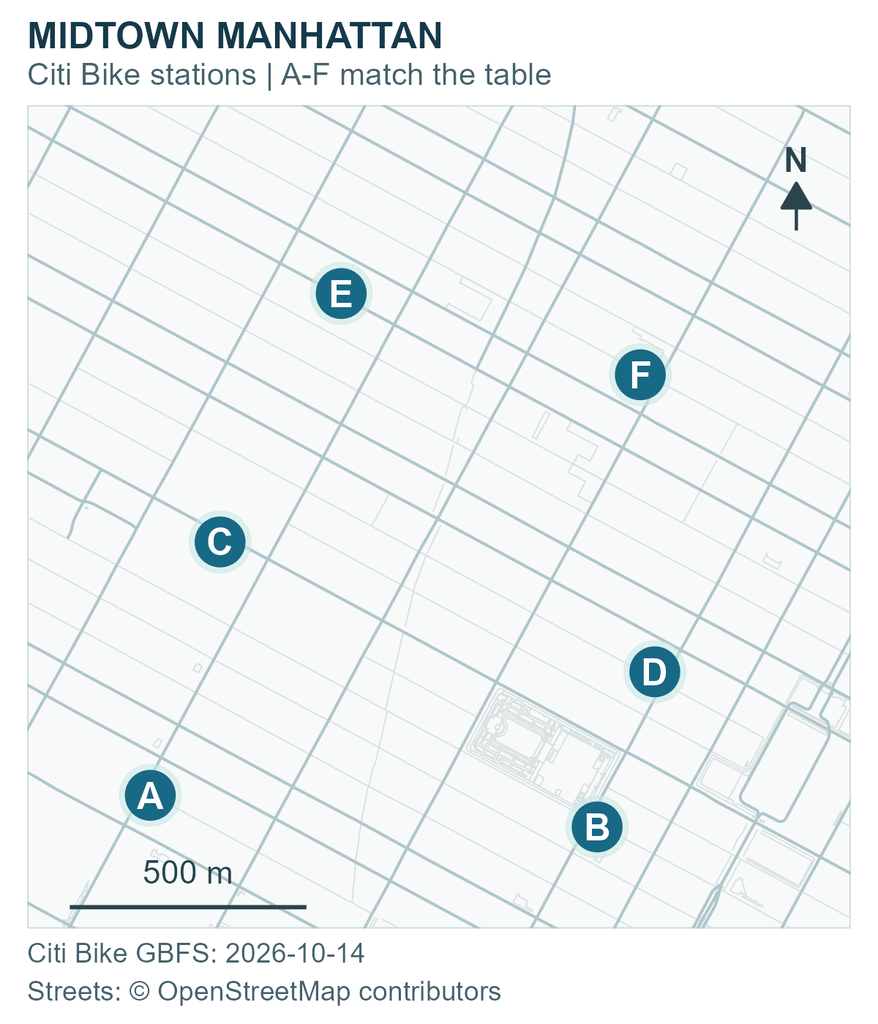

纽约中城的六座 Citi Bike 站点（A—F 与左表对应）

`geometry` 是 `sfc_POINT` 几何列，表中的 `POINT (x y)` 是便于阅读的文本表示。这里 `x = 经度`、`y = 纬度`，CRS 为 EPSG:4326。**点的几何维度是 0**，没有长度或面积；定位仍需两个坐标值。站点资料来自 [Citi Bike 官方站点信息](https://gbfs.citibikenyc.com/gbfs/en/station_information.json)（2026 年 10 月 14 日快照），背景道路来自 [OpenStreetMap](https://www.openstreetmap.org/copyright)。

点分布与统计单元

原始点记录可以逐条绘制。若把同一批点汇总到行政区或网格，统计结果还会受到单元划分方式的影响。[**可变面元问题**](https://www.restore.ac.uk/geo-refer/91023cwors00y00000000.php)（Modifiable Areal Unit Problem, MAUP）包括两种常见情形：**尺度效应**指单元变大或变小时，局部差异可能被平滑或放大；**分区效应**指单元数量与大小相近，但边界位置改变后，各单元的计数、均值或相关性仍可能改变。

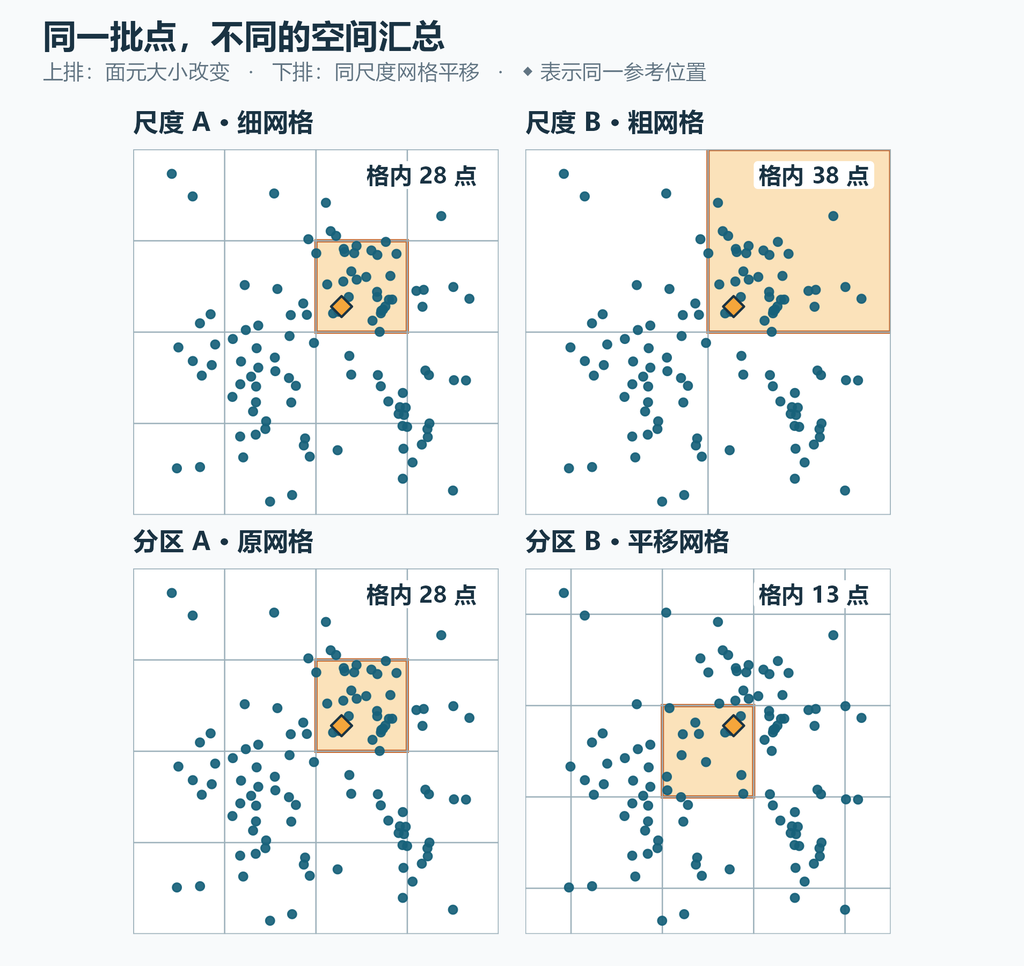

同一批模拟点：面元大小与边界改变格内计数

布鲁克林一块 $6\times6$ km 的研究窗口内有 **380 座 Citi Bike 站点**。下图把同一批点汇总到不同网格，统一以每平方千米的站点数表示。

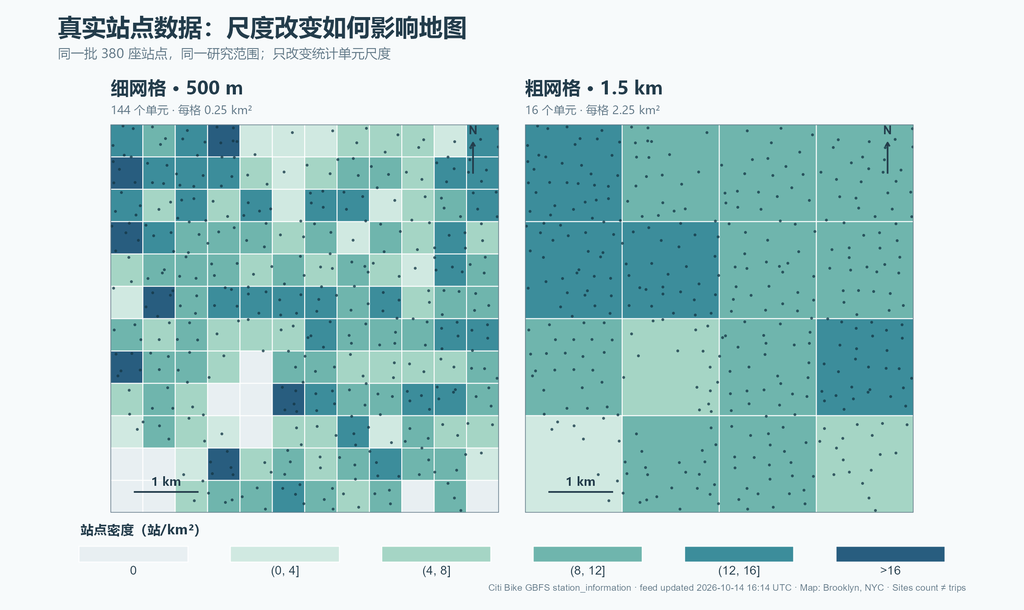

同一批 380 座站点：500 m 与 1.5 km 网格下的站点密度

**尺度改变**时，500 m 网格有 10 个零站点单元；合并为 1.5 km 网格后，16 个单元都包含站点，局部空白随之消失。再保持每格面积为 $3\text{ km}^2$，分别采用 $2\times1.5$ km 与 $1.5\times2$ km 的矩形网格，比较边界划法：

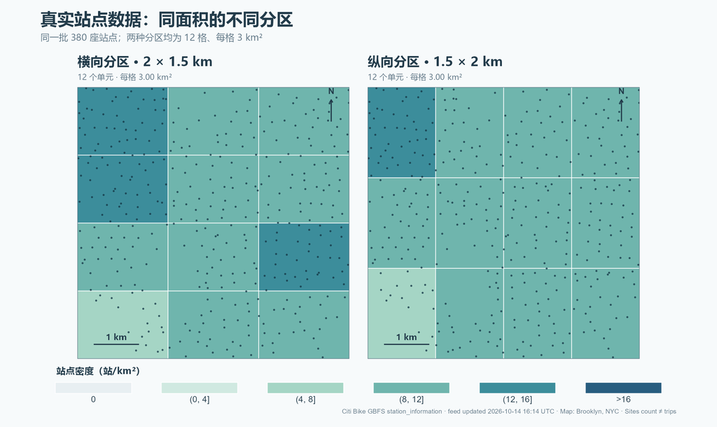

同一批 380 座站点：单元面积相同、网格方向不同时的站点密度

两组图使用同一批站点与同一研究范围，只改变统计单元。若将**超过 12 站/km²**视为高密，横向划分有 **3 格**达到阈值，纵向划分仅有 **1 格**。站点数据来自 [Citi Bike 官方站点信息](https://gbfs.citibikenyc.com/gbfs/en/station_information.json)（2026 年 10 月 14 日快照）。

**选举中的分区效应（模拟）**

九个相邻小格各投出 10 张有效选票，A、B 代表两方。图中票数均按 A∶B 书写；细线区分小格，粗线围出选区。每区由三个小格组成，合计后票数较多的一方获得该区一席。下面只改变分区方向，选票总数始终为 A 48、B 42。

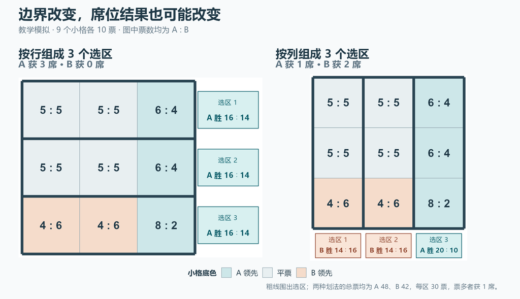

同一批模拟选票：按行或按列划区，区内合计票数决定席位

**按行划区**：三行各为 A 16∶B 14，A 获得 **3 席**。

**按列划区**：前两列各为 A 14∶B 16，第三列为 A 20∶B 10；A 获得 **1 席**，B 获得 **2 席**。

左图最下行虽有两个小格由 B 领先，合计后仍由 A 胜出。小格底色不能直接当作选区胜负。同一批选票汇总到不同选区，席位分配便可能改变；解读按区汇总的结果时，需要说明分区方案。

**展开核对选区票数**

以左图最下行为例：A 获得 $4+4+8=16$ 票，B 获得 $6+6+2=14$ 票，因此这一选区由 A 获得一席。换成右图第一列，A 为 $5+5+4=14$ 票，B 为 $5+5+6=16$ 票，因此这一选区由 B 获得一席。

#### **1.1 常见的空间点记录**

餐厅是地点；在餐厅发生的一次签到是事件。以下按记录对象与形成方式介绍四类常见点数据。

##### **1. 地点与设施点（POI）**

兴趣点（Point of Interest, POI）通常表示一家商店、一座车站、一个公园入口等可定位的地点。名称、类别、营业信息或服务评分可以作为属性。若对象本身有面积，地图上的点通常是入口或代表位置，并不等于它的完整范围。

POI 可用于观察设施分布、服务覆盖和不同功能的邻近关系。平台收录规则与更新频率会影响点数。[Inside Airbnb](https://beta.insideairbnb.com/data-assumptions/) 的房源点位经过位置偏移，不能当作精确门牌位置。

下面四幅图截取伦敦、纽约、巴黎和东京各一块约 $1.6\times1.6$ km 的街区，按相同规则绘出 OpenStreetMap 中标注的咖啡馆、图书馆与博物馆。

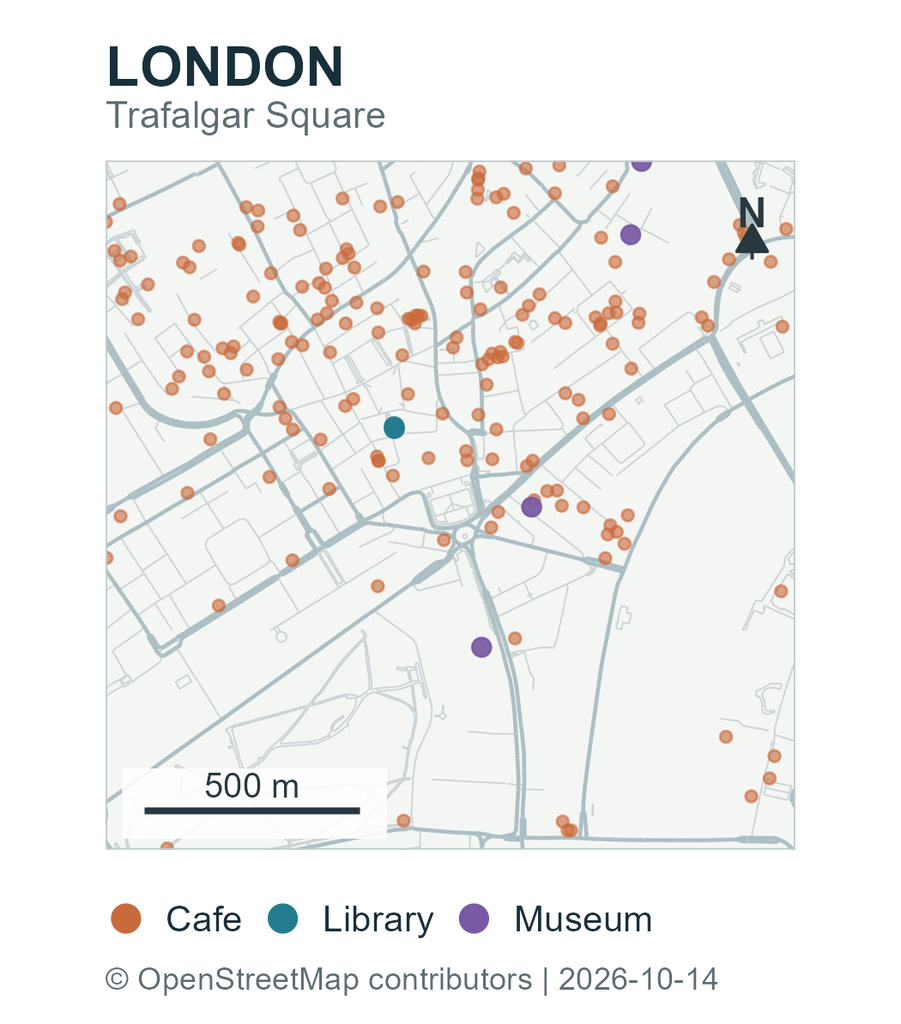

伦敦 · 特拉法加广场周边

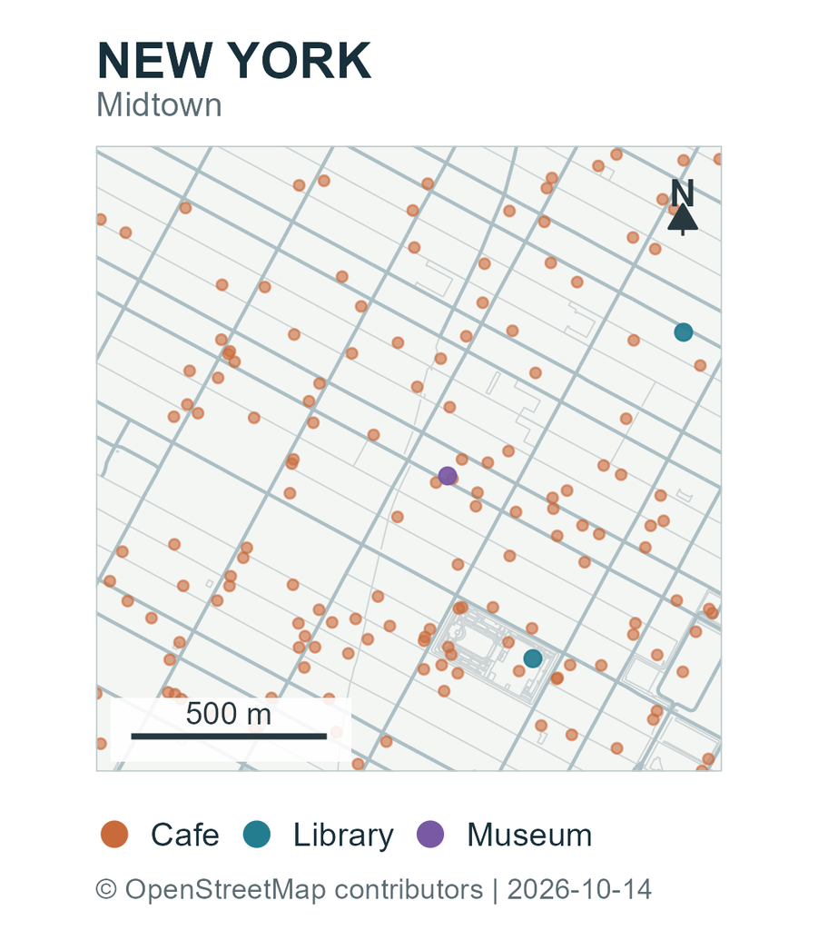

纽约 · 曼哈顿中城

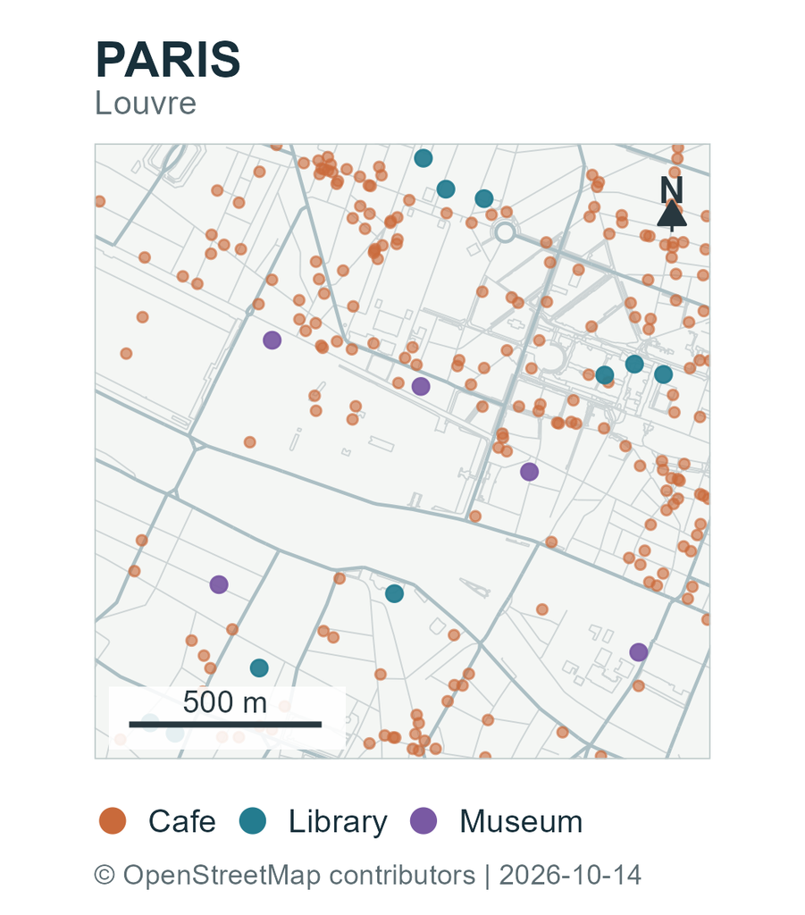

巴黎 · 卢浮宫周边

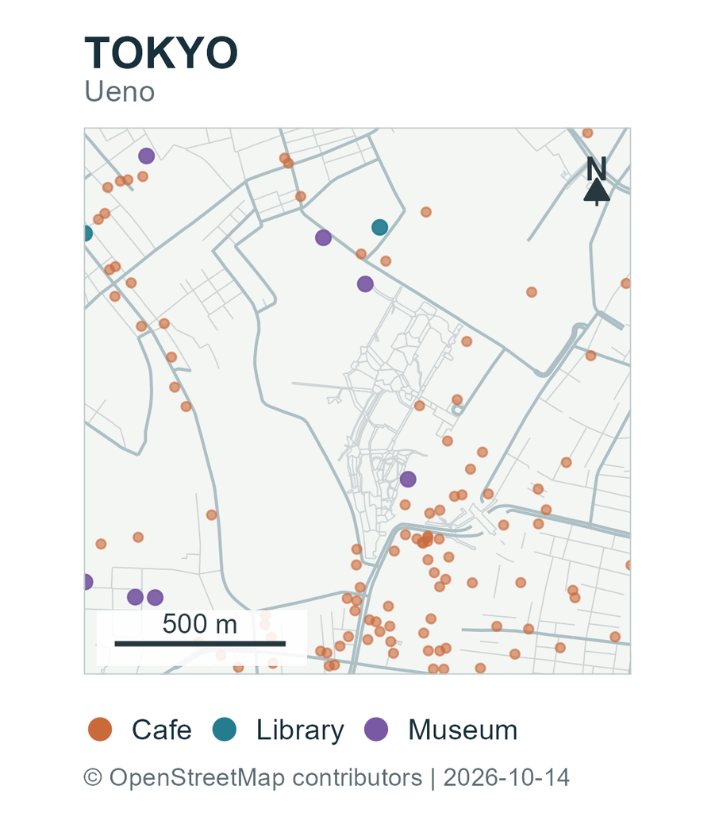

东京 · 上野周边

地图数据：[© OpenStreetMap contributors](https://www.openstreetmap.org/copyright)，提取时间为 2026 年 10 月。

##### **2. 行为与事件点**

事件记录通常说明**何时、何地发生了什么**。一次纽约市 311 非紧急市政服务请求、交通事故或社交媒体签到都可以作为点记录；时间信息有时精确到分钟，有时只有日期。位置也可能由地址或路口转换而来，因此不一定是事件发生的精确坐标。

同一地点可以反复产生记录。按时段绘图可观察记录数量与分布的变化；平台用户构成、上报意愿和数据缺漏会影响观察到的空间分布。

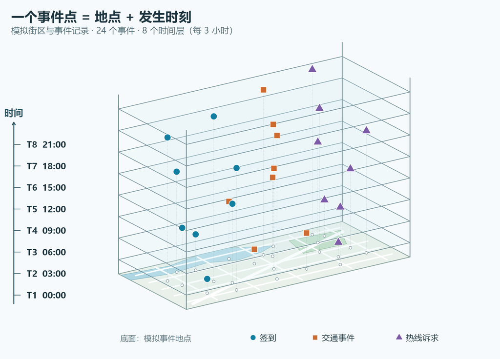

事件点的位置与发生时刻（模拟示意）

图中的街区和事件均为模拟资料。八个时间层覆盖一天，相邻时间层间隔三小时；高度表示发生时刻，不表示事件强度。

##### **3. 轨迹采样点与起讫点**

**轨迹**由同一移动对象按时间排序的位置采样点组成。两个采样点之间的实际路径通常没有被直接记录；采样间隔、定位误差和信号缺失都会影响路线判断。**起讫记录**（OD）则成对保存一趟行程的起点（Origin）与终点（Destination），可能另有出发时间、到达时间或交通方式。

OD 可以由完整轨迹简化，也可以来自租借、进出站等系统记录。地图上连接起终点的直线只表示两地之间存在行程，**不代表实际经过的道路**。

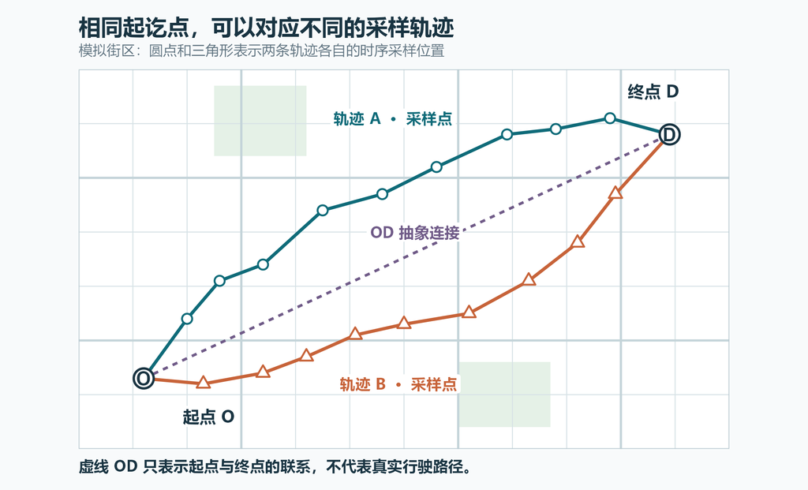

两条模拟轨迹的采样点与同一起讫关系

##### **4. 从其他空间对象得到的代表点**

有些点由行政区、建筑轮廓等面对象计算而来，用于摆放标签、表示区域位置或连接区域间的 OD 关系。

| 表示方式 | 常见用途 | 解释时注意 |
| --- | --- | --- |
| 几何重心 `st_centroid()` | 概括形状的几何位置 | 凹形或带孔的面，其重心可能落在面外。 |
| 面内点 `st_point_on_surface()` | 在面上放置符号或标签 | 点位于面上，但未必接近居民或活动集中的位置。 |
| 人口加权质心 | 表示人口分布的重心 | 依赖人口及其空间分布数据，也可能落在区域边界外。 |

**延伸阅读 · 这些点数据从哪里来？**

- **地点与事件**：[OpenStreetMap](https://www.openstreetmap.org/) 的公开要素可通过 `osmdata` 与 Overpass 查询；[NYC 311 数据页](https://data.cityofnewyork.us/Social-Services/311-Service-Requests-from-2020-to-Present/erm2-nwe9/about_data) 提供市政服务请求记录。
- **行程**：[Citi Bike](https://citibikenyc.com/system-data) 公开逐次骑行的起终点站记录；[NYC TLC](https://www.nyc.gov/site/tlc/about/tlc-trip-record-data.page) 的现行出租车公开数据主要使用出租车分区标识起终地，不能当作连续 GPS 轨迹。
- **平台数据**：社交媒体签到由用户发布，商业 POI 由平台收录；数据开放程度和空间覆盖因平台而异。

**© 华东师范大学 社会发展学院 人口研究所** | [**DAWN 研究组**](https://dawn-ecnu.github.io) | yzliu@soci.ecnu.edu.cn

课程负责人：刘贇喆 本章作者：刘贇喆 | 敖漪宇

最后更新：2026年10月20日 构建环境：R version 4.6.1 (2026-06-24 ucrt)

[CC BY-NC-SA 4.0](https://creativecommons.org/licenses/by-nc-sa/4.0/deed.zh) 回到顶部

## **2.0 点数据实战 1**

### **2.0 专题研究 1：曼哈顿 Airbnb 每夜报价**

#### **专题研究 1：从房源点到空间关联**

##### **分析导航**

**曼哈顿 Airbnb 空间探索流程**

本例从曼哈顿主岛的三期公开记录出发，统一为 **30 夜入住报价**，再依次完成价格分布检查、同坐标合并、六边形聚合与空间关联分析。

**© 华东师范大学 社会发展学院 人口研究所** | [**DAWN 研究组**](https://dawn-ecnu.github.io) | yzliu@soci.ecnu.edu.cn

课程负责人：刘贇喆 本章作者：刘贇喆 | 敖漪宇

最后更新：2026年10月20日 构建环境：R version 4.6.1 (2026-06-24 ucrt)

[CC BY-NC-SA 4.0](https://creativecommons.org/licenses/by-nc-sa/4.0/deed.zh) 回到顶部

##### 研究课题

###### **2.1 研究问题与 ESDA 框架**

平台住宿的地理分布连接着旅游、居住与城市空间等议题。Airbnb 上的房源既有整套住宅，也有私人房间等不同类型；同一城市内部的公开报价也可能呈现空间差异。本例以**曼哈顿主岛**为研究区，从房源点出发，学习如何描述这些差异并检验相邻地区的价格关联。

使用的数据来自 [Inside Airbnb](https://insideairbnb.com/get-the-data/) 的三个公开发布批次。分析统一到**30 夜入住报价的每夜价格**，单位为美元／夜；`price` 已是该次报价折算的每夜金额。研究对象是特定报价条件下可观测房源的价格，后续各步均沿用这一口径。

#### 本例的研究问题

在 2026 年 3、6、9 月三个发布批次中，曼哈顿主岛 30 夜入住的常见每夜报价如何分布？汇总到六边形后，中位报价是否呈现相邻关联？显著的局部高低值组合出现在哪里？

**ESDA 如何组织这一研究？**

探索性空间数据分析 （exploratory spatial data analysis, ESDA） 将地图、分布图和空间统计结合起来，用于描述空间差异、识别集聚与离群，并形成后续研究假设。[Anselin、Syabri 与 Kho（2006）](https://doi.org/10.1111/j.0016-7363.2005.00671.x) 对这类方法及其联系作了系统介绍。本例按下列框架展开：

| 分析环节 | 要回答的问题 | 本例的实现 |
| --- | --- | --- |
| 研究对象与数据检查 | 一条记录代表什么，价格是否可比？ | 主岛边界、报价夜数、价格缺失与分布检查。 |
| 可视化与空间聚合 | 差异在哪里，采用什么统计单元？ | 三期点图；P5–P95 筛选、同坐标合并与六边形中位价。 |
| 空间权重 | 哪些格算作“周围”？ | 有效六边形的 Queen 邻接与行标准化权重 $W$。 |
| 全局关联 | 相近报价是否倾向于相邻？ | 全局 Moran’s I、散点图与随机置换检验。 |
| 局部关联 | 哪些格与周围相似，哪些形成反差？ | 局部 Moran 指标、局部检验与多重比较调整。 |
| 反思与再分析 | 哪些判断依赖样本或尺度选择？ | 对照价格范围、网格尺度、点数门槛与空间权重。 |

这里需要区分**房源的位置分布**与**报价的空间关联**。点图可展示房源集中在哪里；本例的 Moran 分析则检验六边形的报价属性。房源数量多的地区，并不必然具有较高的中位报价。

#### 分析单位

原始表的一行是一条**房源—批次记录**；合并后的一个点是一个**公开坐标**；空间统计的一条观测是一个**六边形**。后续每一步均标明所用的统计单位。

**先认识三个方法概念**

| 概念 | 含义 | 在本例中如何使用 |
| --- | --- | --- |
| 空间权重 $W$ | 明确单元间的邻接关系及权重。 | 将“周围”落实为可计算的邻居集合。 |
| 全局 Moran’s I | 概括整个研究区中属性值与其空间滞后的关联。 | 判断相近的六边形中位报价是否倾向于相邻。 |
| LISA 与局部 Moran | 局部空间关联指标 （local indicators of spatial association, LISA） 是一类指标；本例采用其中的局部 Moran。 | 区分显著的同向集聚与空间离群格。 |

**方法延展 · 空间权重、Moran 散点图与 LISA**

**1. 把“邻近”写成空间权重。** Rook 邻接要求两个面共享边，Queen 邻接允许共享边或顶点；距离阈值与最近邻规则则按位置间的距离确定邻居。下图用方格说明两种接壤规则。

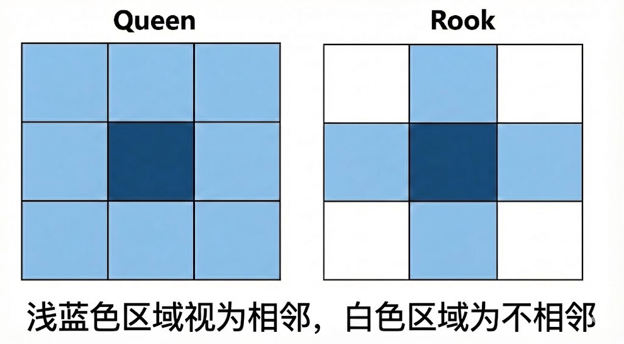

方格上的 Queen 与 Rook 邻接；浅蓝色表示中心格的邻居。

规则六边形密铺中，Queen 与 Rook 通常得到相同邻接；本例的有效格也已核对为相同。距离阈值或最近邻规则可提供不同的“周围”定义。完整说明见 [GeoDa 接壤权重教程](https://geodacenter.github.io/workbook/4a_contig_weights/lab4a.html)。

本例采用行标准化：若第 $i$ 格有 $k_i$ 个邻居，则各邻居的权重为 $1/k_i$，其他格的权重为零。令 $z_i$ 为第 $i$ 格标准化后的中位报价，空间滞后 （spatial lag） 为

$$(Wz)_i=\sum_j w_{ij}z_j.$$

因此，$Wz$ 可理解为邻居标准化报价的加权平均。统计使用的 $W$ 在**达到点数门槛的完整六边形**上构建；地图的海岸遮罩只用于显示。

**2. 全局 Moran’s I 与散点图。** 一般形式为

$$I=\frac{n}{S_0}\frac{\sum_i\sum_j w_{ij}z_i z_j}{\sum_i z_i^2},
\qquad S_0=\sum_i\sum_j w_{ij}.$$

其中 $n$ 是有效格数，$S_0$ 是全部权重之和。正向关联表示相似数值倾向于相邻，负向关联表示相邻单元更常呈现反差。随机重排属性值时，期望为 $-1/(n-1)$，在样本量较大时接近零；统计量的可达范围取决于 $W$。

本例无孤立格，行标准化后 $S_0=n$。以 $z$ 为横轴、$Wz$ 为纵轴，通过原点拟合的斜率等于 Moran’s I。全局置换检验固定格网位置与 $W$，随机重排价格，比较观测到的关联是否超出这种随机排列下常见的程度。参见 [Moran（1950）的经典文献](https://doi.org/10.1093/biomet/37.1-2.17) 与 [GeoDa 全局空间自相关教程](https://geodacenter.github.io/workbook/5a_global_auto/lab5a.html)。

**3. 从四象限走向局部检验。** [Anselin（1995）](https://doi.org/10.1111/j.1538-4632.1995.tb00338.x) 提出了 LISA 框架。下表中的高低均相对于**本次有效格的整体均值**；纵轴对应周围格的加权平均。

| 组合 | 该格 | 周围格 | 含义 |
| --- | --- | --- | --- |
| High–High（HH） | 高 | 高 | 相对高值的同向集聚。 |
| Low–Low（LL） | 低 | 低 | 相对低值的同向集聚。 |
| High–Low（HL） | 高 | 低 | 高值格与周围形成反差。 |
| Low–High（LH） | 低 | 高 | 低值格与周围形成反差。 |

象限先描述方向，局部检验再判断是否达到显著性门槛。本例采用局部条件置换，并用 Benjamini–Hochberg（BH）法调整多重检验的 $p$ 值，最终绘制达到门槛的格。方法说明见 [GeoDa 局部空间自相关教程](https://geodacenter.github.io/workbook/6a_local_auto/lab6a.html)；R 的具体实现见 [spdep 的局部置换文档](https://r-spatial.github.io/spdep/reference/localmoran.html)。

**延伸阅读 · Airbnb、租差与城市住房研究**

空间探索可以衔接更具体的城市研究问题：高报价集聚区与旅游设施是否重合？房型构成是否解释部分地区差异？平台住宿供给与长期租赁、社区变化有怎样的关系？

- **纽约与租差。** Wachsmuth 与 Weisler（2018）的 *Airbnb and the rent gap: Gentrification through the sharing economy* 将纽约 Airbnb 的地理差异与租差、绅士化联系起来。可阅读[期刊原文入口](https://doi.org/10.1177/0308518X18778038)或[作者公开稿](https://upgo.lab.mcgill.ca/publication/airbnb-and-the-rent-gap/airbnb-and-the-rent-gap.pdf)，了解如何把空间格局转化为城市研究问题。租差指现有土地使用获得的地租与潜在更高地租之间的差额。
- **住房价格与租金。** Barron、Kung 与 Proserpio（2021）的 *The Effect of Home-Sharing on House Prices and Rents: Evidence from Airbnb* 研究平台住宿与住房市场的关系。[论文入口](https://doi.org/10.1287/mksc.2020.1227)可用于比较：检验价格关联，与识别 Airbnb 对租金或住房价格的影响，需要哪些不同资料和研究设计？

本例完成的是报价格局的 ESDA。上述机制可作为后续研究方向，需要补充住房、房型、设施及时间变化等资料再检验。

**© 华东师范大学 社会发展学院 人口研究所** | [**DAWN 研究组**](https://dawn-ecnu.github.io) | yzliu@soci.ecnu.edu.cn

课程负责人：刘贇喆 本章作者：刘贇喆 | 敖漪宇

最后更新：2026年10月20日 构建环境：R version 4.6.1 (2026-06-24 ucrt)

[CC BY-NC-SA 4.0](https://creativecommons.org/licenses/by-nc-sa/4.0/deed.zh) 回到顶部

##### 研究区域与数据

###### **2.2 研究区与三期数据**

纽约市有五个行政区。本例仅取曼哈顿行政区中面积最大的连续多边形，即**曼哈顿主岛**；罗斯福岛等离岛不在分析范围内。定位附图显示主岛在纽约市的位置。

[figure not shown]

曼哈顿主岛研究区及其在纽约市的位置；右侧定位图标出五个行政区。

#### 认识研究地点

纽约市 （New York City, NYC） 由 Manhattan、Brooklyn、Queens、The Bronx 和 Staten Island 五个行政区 （boroughs） 组成，位置见上图右侧。**曼哈顿主岛与曼哈顿行政区的范围不同**：行政区还包括 Marble Hill 和若干小岛。五区关系可查阅 [NYC311 官方说明](https://portal.311.nyc.gov/article/?kanumber=KA-02877)，行政区范围见[纽约市行政法典](https://codelibrary.amlegal.com/codes/newyorkcity/latest/NYCadmin/0-0-0-97)。

主岛位于 Hudson River 与 East River 之间，岛体狭长；中央公园、街网和沿岸水域形成清楚的地理参照。研究限定在主岛，既便于观察岛内报价差异，也便于明确分析边界。

**城市延展 · 从纽约影像到曼哈顿街景**

先从国际空间站视角辨认曼哈顿及周边水域，再进入时代广场与中央公园，观察商业街道、公共绿地和高层建筑的空间差异。以下四张真实照片摄于 **2025—2026 年**，分别提供城市区域与街道尺度的背景。

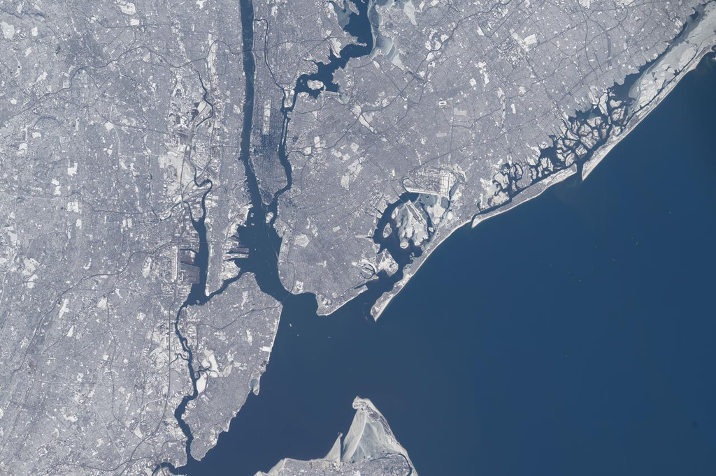

纽约日景｜2026-02-13。国际空间站视角。NASA/Chris Williams，iss074e0315625。

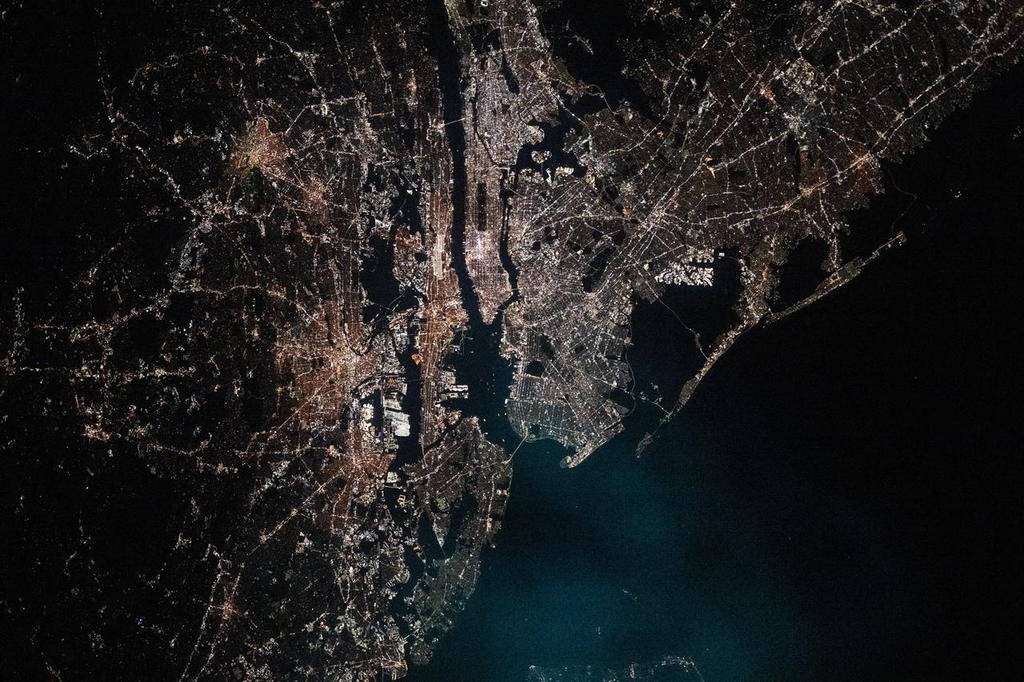

纽约夜景｜2025-09-11。城市灯光与水域。NASA，iss073e0658285。

[figure not shown]

时代广场｜2025-08-31。娱乐商业区的屏幕与人流。Nielsoncaetanosalmeron，CC BY 4.0。

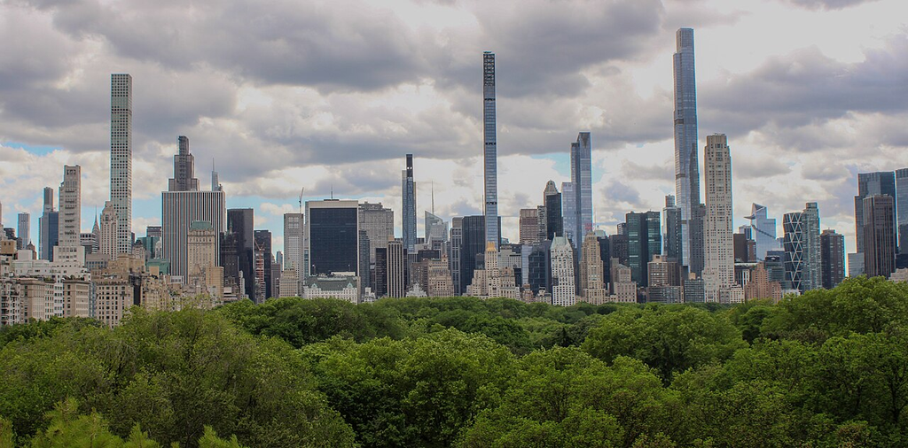

中央公园与中城｜2025-05-19。从大都会艺术博物馆望出。Boaventuravinicius，CC BY 4.0。

原图与说明：[NASA 日景](https://images.nasa.gov/details/iss074e0315625) · [NASA 夜景](https://images.nasa.gov/details/iss073e0658285) · [时代广场](https://commons.wikimedia.org/wiki/File:Times_Square,_NYC_at_night_-_August_2025.jpg) · [中央公园](https://commons.wikimedia.org/wiki/File:Central_Park_seen_from_the_Metropolitan_Museum_May_2025.jpg)。NASA 影像按其[教育与信息用途指引](https://www.nasa.gov/nasa-brand-center/images-and-media/)使用；后两张来自 Wikimedia Commons，按 [CC BY 4.0](https://creativecommons.org/licenses/by/4.0/)署名。网页仅调整图片尺寸和编码压缩，保留原始画面比例。

**Airbnb 与 Inside Airbnb 提供什么资料？**

[Airbnb](https://www.airbnb.com/help/article/5) 是连接房东与旅客的住宿平台，房源包含整套房源、私人房间等类型。[Inside Airbnb](https://insideairbnb.com/about/) 是独立整理平台公开信息的项目，提供房源、日历与评论等数据下载。一次发布是当时可见信息的**快照**：同一房源可以在不同批次出现，房源上下架及信息更新也会改变样本。

本例使用房源位置与公开报价。Inside Airbnb 的[数据说明](https://insideairbnb.com/data-assumptions/)指出，公开坐标经过匿名化，与实际地址可能相差约 0–150 m。因此，同坐标合并是本例的数据处理规则，合并结果以“公开坐标点”计数。

Inside Airbnb 在 **2026 年 1—9 月**公开的纽约市详细房源文件中，可用于本例的是 **3 月 16 日、6 月 14 日和 9 月 14 日**三个发布批次。原始文件见 [Inside Airbnb 数据目录](https://insideairbnb.com/get-the-data/)，再发布数据时须核对其[数据使用政策](https://insideairbnb.com/data-policies/)。

| 字段与记录 | 本例的读取方式 | 用途 |
| --- | --- | --- |
| `id` 与发布批次 | 同一批次中每个房源 ID 至多一条记录；同一房源可跨批次出现。 | 检查重复记录及批次构成。 |
| `longitude`、`latitude` | 房源的公开经纬度。 | 限定主岛、合并同坐标及空间聚合。 |
| `price` | 本次公开报价折算的每夜金额。 | 价格检查、筛选与汇总。 |
| `price_quote_checkin_date`、`price_quote_checkout_date` | 入住日与退房日；两者相减得到报价夜数。 | 统一为恰好 30 夜的报价。 |
| `minimum_nights`、`room_type` | 最低入住限制及房型。 | 理解报价条件与开展分组分析。 |

#### 发布日期、入住日期与每夜报价

发布批次记录数据的发布时间；实际报价的入住、退房日期由 `price_quote_checkin_date` 与 `price_quote_checkout_date` 给出。本例用两者之差选择**恰好 30 夜**的报价，实际入住日期可以跨到下一年。

`minimum_nights` 是房源的最低入住限制，不等于本次报价夜数。`price` 已是**每夜报价**，无需再除以 30；本例的 30 夜记录均可与报价总额除以 30 核对到美分。

三期汇总得到的是这些批次中可观测报价的空间概括，时间覆盖为三个快照；它不构成连续九个月的成交记录。

**制度背景 · 纽约的短租登记与 30 夜口径**

纽约市 Local Law 18 要求短租房东登记，平台自 2023 年 9 月起执行相应的登记验证；连续 30 天及以上的住宿免于这一短租登记要求，见 [NYC 官方说明](https://www.nyc.gov/site/specialenforcement/registration-law/registration.page)。这一制度背景有助于理解纽约长住报价的研究语境。

本例固定 30 夜，是为统一**报价对应的入住时长**；房型、可住人数、入住日期与折扣仍可能不同。

下列代码优先读取本机缓存；缓存不存在时从官方地址下载。地图边界优先读取本例保存的曼哈顿主岛边界，缺失时从纽约市边界服务获取。

**先检查价格字段。** 下表将三期原表与曼哈顿主岛记录分别按价格状态计数。“价格缺失”包括空白值；“解析失败”指非空价格无法转换为数值。

三期 Airbnb 价格字段状态

| 统计范围 | 记录数 | 价格缺失 | 解析失败 | 负价 | 零价 | 正价 |
| --- | --- | --- | --- | --- | --- | --- |
| 纽约市三期原表 | 96,156 | 33,800 | 0 | 0 | 0 | 62,356 |
| 曼哈顿主岛 | 43,589 | 15,853 | 0 | 0 | 0 | 27,736 |

这三期数据中没有负价或零价；主岛内有 **15,853 条价格缺失记录**。主岛内的 **27,736 条正价记录**包含不同入住时长的报价。下方分析统一使用其中 **19,061 条 30 夜报价记录**，再检查其价格分布。

三张地图共用范围、Fisher 七级断点与 viridis 色盘。分类在合并三期 30 夜报价的 `log10` 尺度上计算，图例仍以美元／夜表示。

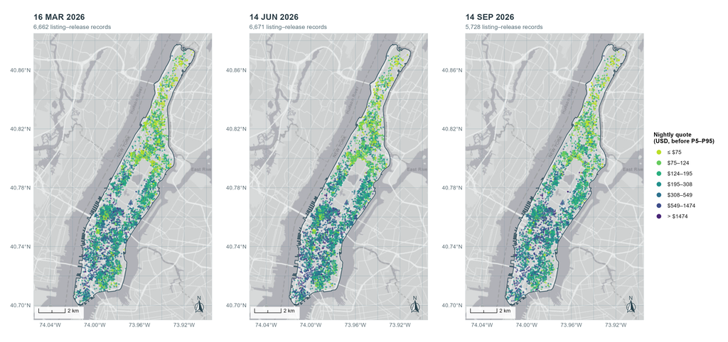

2026 年三期曼哈顿主岛 30 夜入住报价；三幅地图共用 Fisher 七级断点。

**查看并复制数据读取、研究区与价格检查 R 代码**

```r
Sys.setlocale("LC_CTYPE", ".UTF-8")
local_library <- file.path("figures", "manhattan_2026_multisnapshot_prototype", "R_library")
if (dir.exists(local_library)) .libPaths(c(local_library, .libPaths()))
library(dplyr)
library(readr)
library(sf)
library(ggplot2)

data_dir <- "figures/manhattan_2026_multisnapshot_prototype/data"
release_dates <- c("2026-03-16", "2026-06-14", "2026-09-14")
source_base <- "https://data.insideairbnb.com/united-states/ny/new-york-city"

read_release <- function(release_date) {
  file_path <- file.path(data_dir, paste0("nyc_", release_date, ".csv.gz"))
  if (!file.exists(file_path)) {
    dir.create(data_dir, recursive = TRUE, showWarnings = FALSE)
    source_url <- paste0(source_base, "/", release_date, "/data/listings.csv.gz")
    download.file(source_url, file_path, mode = "wb")
  }
  quote_fields <- c("id", "longitude", "latitude", "price", "room_type",
                    "minimum_nights", "price_quote_checkin_date",
                    "price_quote_checkout_date", "price_quote_total_price",
                    "price_quote_price_per_night")
  read_csv(file_path,
           col_select = all_of(quote_fields),
           col_types = cols(.default = col_character(),
                            longitude = col_double(), latitude = col_double()),
           show_col_types = FALSE, progress = FALSE) %>%
    mutate(snapshot = release_date,
           price_usd = parse_number(price,
                                    locale = locale(grouping_mark = ",")),
           quote_checkin = as.Date(price_quote_checkin_date),
           quote_checkout = as.Date(price_quote_checkout_date),
           quote_nights = as.integer(quote_checkout - quote_checkin),
           quote_total_usd = parse_number(price_quote_total_price),
           quote_per_night_usd = parse_number(price_quote_price_per_night))
}

listing_rows <- bind_rows(lapply(release_dates, read_release))
stopifnot(!anyDuplicated(listing_rows[c("snapshot", "id")]))

boundary_path <- file.path(data_dir, "manhattan_main_island_original_boundary.gpkg")
if (file.exists(boundary_path)) {
  main_island <- st_read(boundary_path, quiet = TRUE)
} else {
  boundary_url <- paste0(
    "https://services5.arcgis.com/GfwWNkhOj9bNBqoJ/arcgis/rest/services/",
    "NYC_Borough_Boundary/FeatureServer/0/query?where=1=1&outFields=*&outSR=4326&f=pgeojson"
  )
  main_island <- st_read(boundary_url, quiet = TRUE) %>%
    filter(BoroName == "Manhattan") %>%
    st_make_valid() %>%
    st_cast("POLYGON") %>%
    mutate(area_ft2 = as.numeric(st_area(st_transform(geometry, 2263)))) %>%
    slice_max(area_ft2, n = 1, with_ties = FALSE) %>%
    select(BoroName)
  st_write(main_island, boundary_path, quiet = TRUE)
}
main_island <- st_transform(main_island, 4326)
```

```r
# 先检查原表，再用有效坐标确定主岛内的记录；此时尚未筛掉价格缺失值。
valid_location <- is.finite(listing_rows$longitude) &
  is.finite(listing_rows$latitude)
located_rows <- listing_rows[valid_location, ]
on_main_island <- lengths(st_intersects(
  st_as_sf(located_rows, coords = c("longitude", "latitude"), crs = 4326),
  main_island
)) > 0L
main_island_rows <- located_rows[on_main_island, ]

count_price_status <- function(rows, scope) {
  price_missing <- is.na(rows$price) | trimws(rows$price) == ""
  price_valid <- is.finite(rows$price_usd)
  tibble::tibble(
    scope = scope,
    records = nrow(rows),
    missing = sum(price_missing),
    parse_failed = sum(!price_missing & !price_valid),
    negative = sum(price_valid & rows$price_usd < 0),
    zero = sum(price_valid & rows$price_usd == 0),
    positive = sum(price_valid & rows$price_usd > 0)
  )
}
price_eda <- bind_rows(
  count_price_status(listing_rows, "纽约市三期原表"),
  count_price_status(main_island_rows, "曼哈顿主岛")
)
stopifnot(all(price_eda$records == rowSums(price_eda[, -(1:2)])))
price_eda %>%
  mutate(across(-scope, ~ format(.x, big.mark = ",", trim = TRUE))) %>%
  knitr::kable(
    format = "html",
    caption = "三期 Airbnb 价格字段状态",
    col.names = c("统计范围", "记录数", "价格缺失", "解析失败",
                  "负价", "零价", "正价"),
    align = c("l", rep("r", 6))
  )
```

```r
# 先保留有效正价，再按实际入住日期之差统一报价时长。
positive_rows <- main_island_rows %>%
  filter(is.finite(price_usd), price_usd > 0) %>%
  mutate(longitude = round(longitude, 12),
         latitude = round(latitude, 12))
quote_30_rows <- positive_rows %>% filter(quote_nights == 30L)

# price 已经是每夜金额；以下仅做字段一致性检查，不重复折算。
stopifnot(
  nrow(quote_30_rows) > 0L,
  all(abs(quote_30_rows$price_usd - quote_30_rows$quote_per_night_usd) < 0.011),
  all(abs(quote_30_rows$price_usd - quote_30_rows$quote_total_usd / 30) < 0.011)
)
```

**制图之后，按什么顺序读图？**

读图先确认统计对象，再识别模式，最后结合检验形成判断。后续各图均可沿用下列顺序。

| 顺序 | 重点查看 | 在本例中的检查 |
| --- | --- | --- |
| 先认对象 | 研究范围、记录单位与时间。 | 主岛边界；房源—批次记录、坐标点或六边形；三个发布批次。 |
| 再读编码 | 色阶、单位、参照值与未纳入区域。 | 美元／夜；颜色对应的价格区间；少于 5 个坐标的格另列。 |
| 观察模式 | 高低值在哪里，是否相邻，哪里有反差。 | 沿岛体比较南北及东西差异，并关注成片区域与孤立点。 |
| 检验判断 | 视觉模式是否得到统计支持。 | 先用 Moran’s I 概括整体关联，再用局部检验定位显著组合。 |

**本图的基本解读。** 三期点图均可见报价的空间差异：北段较多较低报价点，中南段混合分布着更多较高报价点。点位较密的地方存在遮挡，后续用六边形聚合后再比较区域模式。三个发布批次中的房源构成与实际入住日期不同，跨期价格变化还需在相同报价条件下另行比较。

**© 华东师范大学 社会发展学院 人口研究所** | [**DAWN 研究组**](https://dawn-ecnu.github.io) | yzliu@soci.ecnu.edu.cn

课程负责人：刘贇喆 本章作者：刘贇喆 | 敖漪宇

最后更新：2026年10月20日 构建环境：R version 4.6.1 (2026-06-24 ucrt)

[CC BY-NC-SA 4.0](https://creativecommons.org/licenses/by-nc-sa/4.0/deed.zh) 回到顶部

##### 数据预处理

###### **2.3 价格分布、筛选与同坐标合并**

下图展示 **19,061 条 30 夜正报价记录**的价格分布。直方图展示频数，核密度曲线 （kernel density estimate, KDE） 概括平滑后的分布，底部短线 （rug） 标出各条记录的价格位置。此处 KDE 描述**一维价格分布**；专题研究 2 将进一步学习位置空间中的核密度。

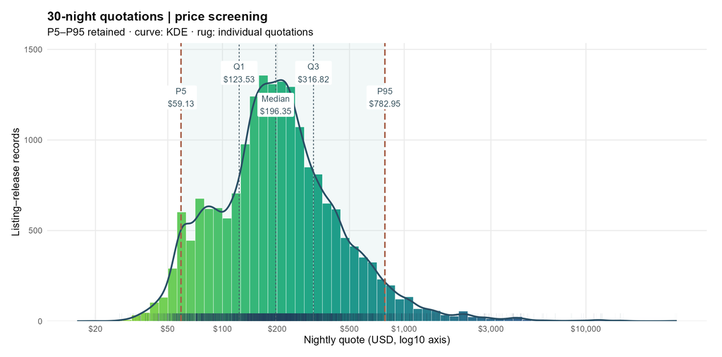

30 夜每夜报价的分布、核密度与观测位置；P5–P95 区间用于后续价格筛选。

图中阴影标出后续纳入的区间。为聚焦常见报价，本例在**房源—批次记录层**合并计算第 5 与第 95 百分位，保留 **59.13–782.95 美元／夜**的闭区间。计算使用 R 默认的 `type = 7`，筛选用未四舍五入的边界值。该选择排除低端 900 条、高端 952 条记录；分位点处存在重复价格，因此实际保留比例约为 **90.28%**。

```
##                  stage count
## 1 主岛 30 夜正报价记录 19061
## 2    P5–P95 筛选后记录 17209
## 3       合并后不同坐标  7792
```

筛选后保留 **17,209 条记录**，合并得到 **7,792 个不同的公开坐标**。同坐标内先求每期均价，再对已观测批次等权平均，避免某一期同点记录较多而主导结果。相同坐标可能对应多套房源，且公开坐标可能经过位置偏移，因此合并后的数量按“坐标点”计。

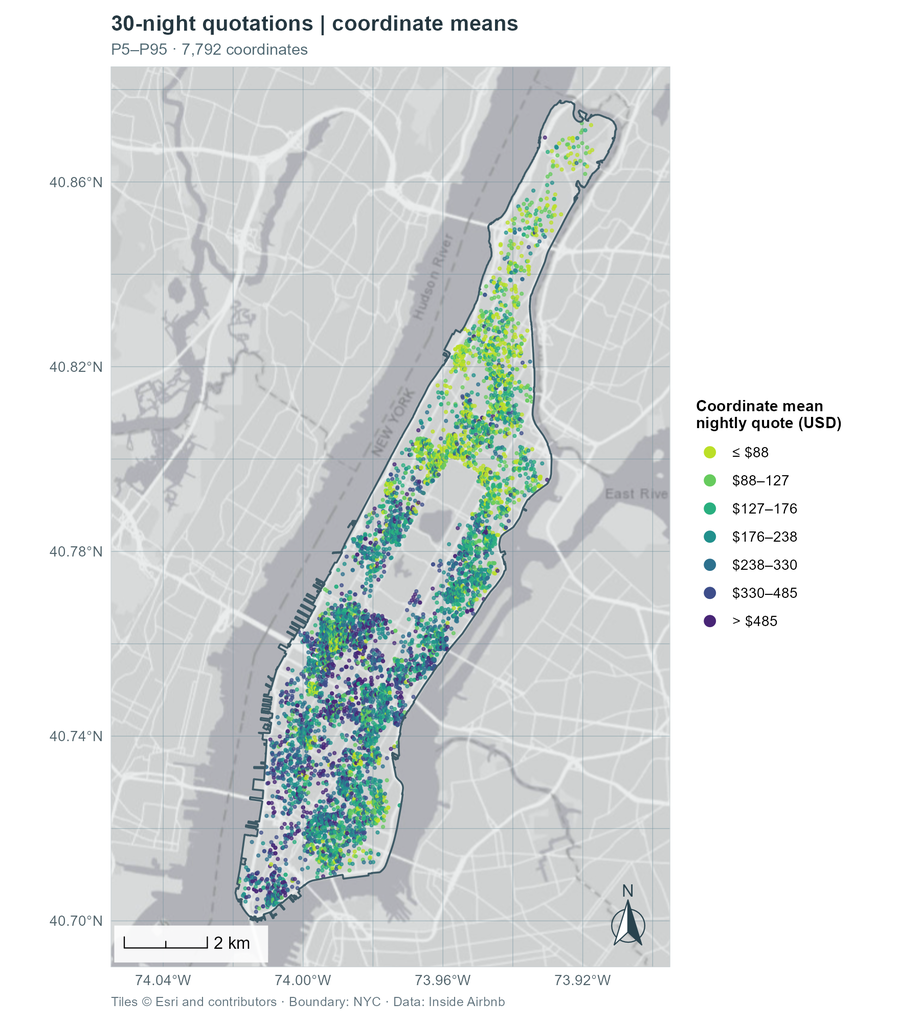

P5–P95 筛选后合并的 7,792 个坐标点；颜色表示坐标均价的 Fisher 七级分类。

**查看并复制价格筛选与坐标合并 R 代码**

```r
# 1. 在房源—批次记录层筛选；同坐标均价留到下一步计算。
# 分位点使用原始精度，包含上下界；图上的两位小数只用于显示。
price_bounds <- quantile(quote_30_rows$price_usd,
                         probs = c(0.05, 0.95), type = 7)
price_lower <- unname(price_bounds[1])
price_upper <- unname(price_bounds[2])
selected_rows <- quote_30_rows %>%
  filter(price_usd >= price_lower, price_usd <= price_upper)

# 2. 同一坐标先求每期均价，再对该坐标出现过的批次等权平均。
# n_releases 是实际出现的批次数，未出现的批次不补零。
gps_price <- selected_rows %>%
  group_by(longitude, latitude, snapshot) %>%
  summarise(release_mean_usd = mean(price_usd), .groups = "drop") %>%
  group_by(longitude, latitude) %>%
  summarise(mean_price_usd = mean(release_mean_usd),
            n_releases = n(), .groups = "drop")

data.frame(
  stage = c("主岛 30 夜正报价记录", "P5–P95 筛选后记录", "合并后不同坐标"),
  count = c(nrow(quote_30_rows), nrow(selected_rows), nrow(gps_price))
)
```

**读图顺序：先看分布，再看筛选后的空间模式。**

1. **辨认横轴。** 分布图采用对数价格轴，相同的横向距离表示相同的价格倍数变化；先找观测集中的价位，再看两端延伸。
2. **合看柱体、曲线与短线。** 柱体反映各区间的记录数，KDE 显示平滑后的峰与尾部，底部短线帮助辨认稀疏的极端记录。
3. **核对筛选范围，再回到地图。** 查看 P5–P95 保留了分布中的哪一段，再观察坐标均价点的高低值位置。筛选后点图重新计算 Fisher 断点，比较前后价格时应核对各自图例。

**本图的发现。** 报价呈右偏长尾，中位数约为 **196 美元／夜**，少量高价记录将右尾拉长。P5–P95 将后续分析限定在常见报价区间；筛选后的坐标均价点仍呈现北段较低、中南段较高的空间差异，随后可检查这种差异在统一面积的网格上如何表现。

分布图的一条观测是**房源—批次记录**，点图的一个点是**合并后的公开坐标**。同坐标跨批次取均价还会平滑部分差异，读图时需要沿用各自的统计单位。

**© 华东师范大学 社会发展学院 人口研究所** | [**DAWN 研究组**](https://dawn-ecnu.github.io) | yzliu@soci.ecnu.edu.cn

课程负责人：刘贇喆 本章作者：刘贇喆 | 敖漪宇

最后更新：2026年10月20日 构建环境：R version 4.6.1 (2026-06-24 ucrt)

[CC BY-NC-SA 4.0](https://creativecommons.org/licenses/by-nc-sa/4.0/deed.zh) 回到顶部

##### 网格化与聚合

###### **2.4 六边形网格与中位价**

逐点着色仍容易重叠。将不同坐标点归入规则六边形后，可比较同一尺度下的报价代表值。本例采用面积 **$0.10\text{ km}^2$**、边长约 **196 m** 的六边形作为教学分析尺度。改变网格大小或起点可能改变结果，可在反思中检验 MAUP 的影响。

面积计算使用 **EPSG:2263**。该坐标系的长度单位是**美国测量英尺**，因此按 $1\text{ m}=3937/1200\text{ ft}$ 换算。统计使用与主岛相交的**完整六边形**；地图显示时才将格网遮罩至主岛边界，并在 **EPSG:4326** 下叠加瓦片底图。

```
##   intersecting_hex eligible_hex excluded_hex
## 1              653          363          290
```

与主岛相交的 **653 格**中，**363 格**至少有 5 个不同坐标点，进入后续空间统计；其余 **290 格**在图中单列为“<5 GPS points”。格内中位数由**坐标均价**计算，不是对原始房源—批次记录再次直接取中位数。

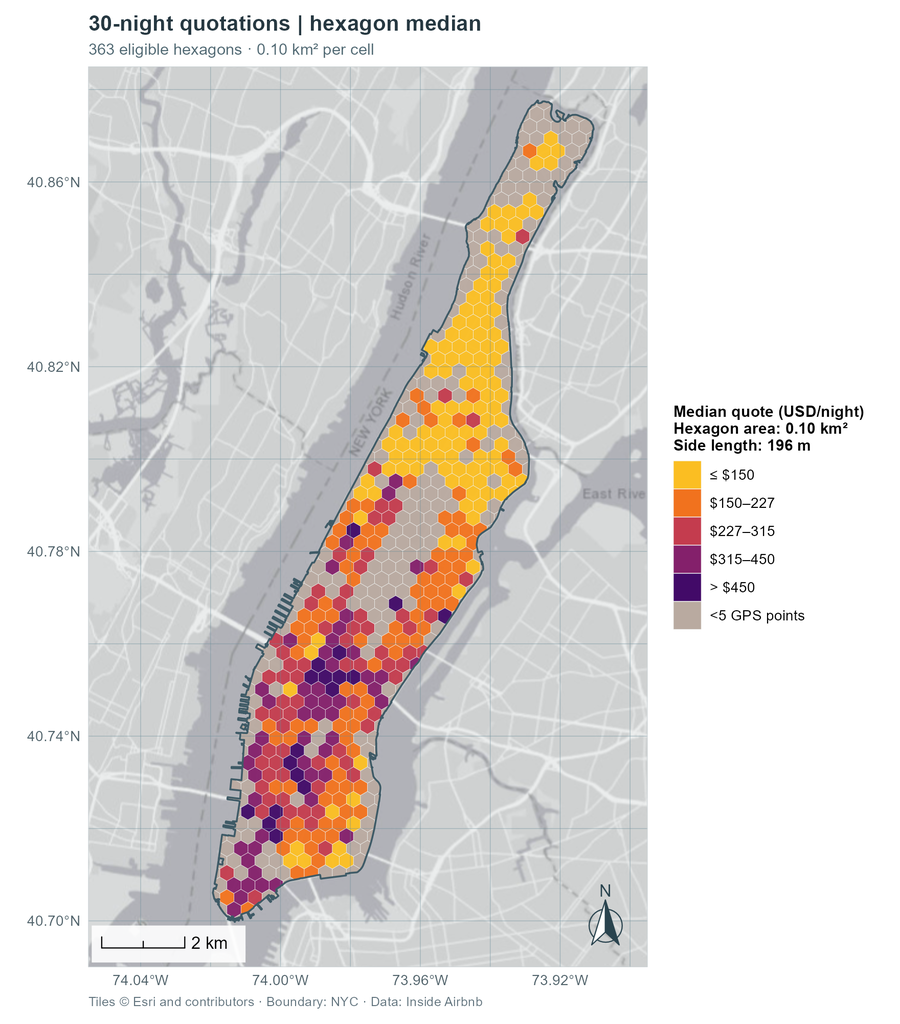

面积 0.10 km²、边长约 196 m 的六边形中位报价；少于 5 个坐标点的格网另列。

**查看并复制六边形网格分析 R 代码**

```r
library(spdep)

main_island_2263 <- st_transform(main_island, 2263)
target_area_m2 <- 100000  # 约 0.1 km²
cellsize_ft <- sqrt(2 * target_area_m2 / sqrt(3)) * (3937 / 1200)
# 1. 按目标面积求对边距离；st_make_grid() 的六边形 cellsize 约为 339.8 m。
# 边长单独计算，用于解释网格尺度。
hex_side_m <- sqrt(2 * target_area_m2 / (3 * sqrt(3)))

hex_grid <- st_make_grid(main_island_2263,
                         cellsize = cellsize_ft, square = FALSE) %>%
  st_sf() %>%
  mutate(hex_id = row_number()) %>%
  st_filter(main_island_2263, .predicate = st_intersects)

gps_2263 <- st_as_sf(gps_price,
                     coords = c("longitude", "latitude"), crs = 4326) %>%
  st_transform(2263)
hex_hits <- st_intersects(gps_2263, hex_grid)
if (any(lengths(hex_hits) == 0)) stop("有 GPS 点落在网格外")

# 2. 边界上的公开坐标若同时接触两格，约定归入编号较小的一格。
# 每个坐标只计一次；中位数的输入是上一阶段的坐标均价。
gps_price$hex_id <- hex_grid$hex_id[vapply(hex_hits, min, integer(1))]
hex_values <- gps_price %>%
  group_by(hex_id) %>%
  summarise(gps_count = n(),
            median_price_usd = median(mean_price_usd), .groups = "drop")

hex_all <- hex_grid %>% left_join(hex_values, by = "hex_id")
# 3. 只有达到点数门槛的格参与空间检验；其余格不补价格零值。
hex_eligible <- hex_all %>% filter(gps_count >= 5) %>% arrange(hex_id)
data.frame(intersecting_hex = nrow(hex_all),
           eligible_hex = nrow(hex_eligible),
           excluded_hex = nrow(hex_all) - nrow(hex_eligible))
```

**读图顺序：覆盖 → 价位 → 邻接模式。**

1. **先看有效范围。** 将有报价色阶的格与“<5 GPS points”分开。后者是坐标数量未达门槛的区域。
2. **再比较价位。** 依图例读出高低报价在哪里，沿岛体比较南北差异，再查看同一地段内部的变化。
3. **最后观察相邻格。** 寻找连续的相近色阶、突变边缘及孤立高低值，形成下一步空间检验的问题。

**本图的发现。** 北段较多有效格落在较低报价等级，中南段出现更多较高报价。部分相邻格颜色接近，也有高低交错的位置。这提示报价差异可能具有区域性，下一步用全局 Moran’s I 检查整体的相邻关联。

每格颜色表示**格内坐标均价的中位数**，Fisher 色阶用于显示。后续检验使用未分级的美元数值，当前地图中的连续同色区域还需要统计检验。

**© 华东师范大学 社会发展学院 人口研究所** | [**DAWN 研究组**](https://dawn-ecnu.github.io) | yzliu@soci.ecnu.edu.cn

课程负责人：刘贇喆 本章作者：刘贇喆 | 敖漪宇

最后更新：2026年10月20日 构建环境：R version 4.6.1 (2026-06-24 ucrt)

[CC BY-NC-SA 4.0](https://creativecommons.org/licenses/by-nc-sa/4.0/deed.zh) 回到顶部

##### 全局空间自相关

###### **2.5 全局 Moran’s I**

按 2.1 的框架，现在把网格图中观察到的差异转为全局检验。这里在 **363 个有效完整六边形**之间构建 Queen 邻接，把邻居权重行标准化为 `W`。邻接图有**三个连通部分**，每个格至少有一个邻居。

```
##     moran_i permutation_p zero_neighbor_hex connected_components
## 1 0.5826373        0.0001                 0                    3
```

下图将每个有效六边形画成一个散点，用该格的标准化中位报价 $z$ 与邻居的加权平均 $Wz$ 展示整体关联。

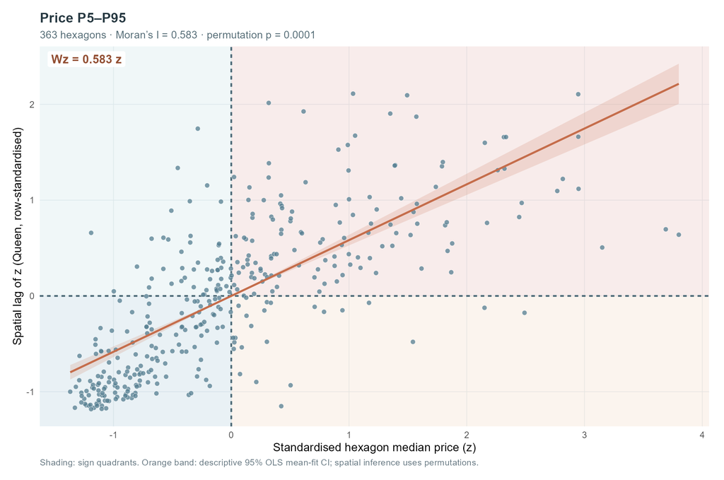

363 个有效六边形的 Moran 散点图；加粗虚线划分四象限，浅色带为描述性拟合区间。

**查看并复制全局空间自相关 R 代码**

```r
# 1. 观测顺序与权重顺序须一致；只对有效完整六边形构建邻接。
neighbors <- poly2nb(hex_eligible, queen = TRUE,
                     row.names = as.character(hex_eligible$hex_id))
neighbor_count <- card(neighbors)
components <- n.comp.nb(neighbors)$nc
weights <- nb2listw(neighbors, style = "W", zero.policy = TRUE)
hex_price <- hex_eligible$median_price_usd

set.seed(20261016)
# 2. moran.test() 提供解析统计量；正文的显著性来自下方置换检验。
global_moran <- moran.test(hex_price, weights,
                           alternative = "greater", zero.policy = TRUE)
global_permutation <- moran.mc(hex_price, weights, nsim = 9999,
                               alternative = "greater", zero.policy = TRUE)

data.frame(moran_i = unname(global_moran$estimate[1]),
           permutation_p = global_permutation$p.value,
           zero_neighbor_hex = sum(neighbor_count == 0),
           connected_components = components)
```

**Moran 散点图的读图顺序**

| 顺序 | 怎样读 | 本图中的含义 |
| --- | --- | --- |
| 1 · 坐标与零线 | 横轴看该格，纵轴看邻居加权平均。 | $z=0$ 对应 363 个有效格中位报价的整体均值；$Wz>0$ 表示邻居的加权平均报价高于这一均值。 |
| 2 · 四个象限 | 看本地高低与周围高低怎样组合。 | 右上为高—高、左下为低—低；左上与右下显示本地和周围的反差。 |
| 3 · 直线与离散 | 看斜率方向，再看散点偏离直线的程度。 | 橙线向右上倾斜，低值侧点云较集中，高值侧的邻域报价更分散。 |
| 4 · 置换检验 | 固定位置与邻接，随机重排报价，再与观测统计量比较。 | 单侧置换 $p=0.0001$，支持本例存在正向空间关联。 |

**$I=0.583$ 说明什么？** 在本次网格、报价口径与 Queen 权重下，报价相似的格倾向于相邻：较高报价格常与较高报价的邻域相伴，较低报价格也常与较低报价的邻域相伴。结合置换检验，可以将六边形地图上观察到的区域差异进一步概括为**显著的全局正向空间自相关**。

**怎样理解回归线？** 本图的直线通过原点，拟合方程为

$$\widehat{Wz}=0.583z.$$

例如，当某格的中位报价高于整体均值 **1 个标准差**时，直线上对应的邻居加权平均约高出整体均值 **0.583 个标准差**。散点与直线的距离显示各格偏离整体关系的程度；高报价一侧仍有较大的邻域差异，整体正向关联与局部反差可以同时存在。

这里的斜率用于描述报价与其空间滞后的关系。全局检验概括全部有效格，显著的具体位置还需由下一步局部检验确定。

**进阶 · 斜率、置信带与全局统计量**

本例对报价做标准化，并采用行标准化权重且无孤立格。此时，通过原点的最小二乘斜率为 $\sum_i z_i(Wz)_i/\sum_i z_i^2$，恰好等于 Moran’s I。$Wz$ 由已经标准化的邻居值计算，纵轴没有再单独标准化。

橙色阴影是该直线的 **95% 均值拟合置信带**。计算采用普通最小二乘，未校正空间依赖；空间自相关的显著性依据是置换检验。$I$ 表示空间关联，其数值不作为价格方差的解释比例。

Moran’s I 综合各格与邻居的偏离均值乘积。远离原点的观测可能有较大贡献，因此还应查看散点中的极端位置。统计量的量级取决于变量、格网和权重，可用相同设定下的敏感性分析比较；方法说明见 [GeoDa 全局空间自相关教程](https://geodacenter.github.io/workbook/5a_global_auto/lab5a.html)。

**© 华东师范大学 社会发展学院 人口研究所** | [**DAWN 研究组**](https://dawn-ecnu.github.io) | yzliu@soci.ecnu.edu.cn

课程负责人：刘贇喆 本章作者：刘贇喆 | 敖漪宇

最后更新：2026年10月20日 构建环境：R version 4.6.1 (2026-06-24 ucrt)

[CC BY-NC-SA 4.0](https://creativecommons.org/licenses/by-nc-sa/4.0/deed.zh) 回到顶部

##### 局部空间自相关

###### **2.6 LISA：局部关联在哪里**

接下来用**局部 Moran**检查每个有效格与周围的报价组合。HH、LL、HL、LH 的含义见 2.1；高低以这 **363 个格的整体均值**为参照，与六边形价格图的 Fisher 等级区分。

本例采用条件置换的双侧模拟 $p$ 值，并对 363 个局部检验用 Benjamini–Hochberg 法调整。只有调整后 $p\leq0.05$ 的格网才按象限标为显著；其他有效格标为“不显著”。

```
##
##       High-High        Low-High         Low-Low Not significant
##              17               1              39             306
```

同一口径下，显著格包括 **17 格 High–High、39 格 Low–Low、1 格 Low–High**，没有显著的 High–Low；**306 格不显著**。图中的“<5 GPS points”表示未进入检验的格，与“不显著”分开显示。

[figure not shown]

三期数据的曼哈顿主岛 LISA 聚类；局部 p 值经 BH 调整。

**查看并复制局部空间自相关 R 代码**

```r
# 1. 沿用相同的格网、价格与权重；独立固定局部检验随机种子。
set.seed(20261016)
local_permutation <- localmoran_perm(hex_price, weights, nsim = 9999,
                                    alternative = "two.sided", iseed = 20261016,
                                    zero.policy = TRUE)
p_column <- "Pr(z != E(Ii)) Sim"
if (!p_column %in% colnames(local_permutation)) {
  stop("当前 spdep 版本未返回预期的双侧模拟 p 值列")
}
# 2. 对所有有效格的局部检验一起做 BH 调整，再用调整后的 p 值判定。
p_bh <- p.adjust(local_permutation[, p_column], method = "BH")

# 3. z 是该格的标准化价格，lag_z 是邻居标准化价格的加权平均。
price_z <- as.numeric(scale(hex_price))
lag_z <- lag.listw(weights, price_z, zero.policy = TRUE)
# 先保留“不显著”，只对达到门槛的格按象限赋予局部类型。
cluster <- rep("Not significant", length(price_z))
significant <- !is.na(p_bh) & p_bh <= 0.05
cluster[significant & price_z > 0 & lag_z > 0] <- "High-High"
cluster[significant & price_z < 0 & lag_z < 0] <- "Low-Low"
cluster[significant & price_z > 0 & lag_z < 0] <- "High-Low"
cluster[significant & price_z < 0 & lag_z > 0] <- "Low-High"
hex_eligible$lisa_cluster <- cluster

table(hex_eligible$lisa_cluster)
```

**LISA 地图的读图顺序**

1. **先区分覆盖与检验状态。** “<5 GPS points”未进入检验；“Not significant”已进入检验，但没有达到 BH 调整后的门槛。
2. **再读高低的参照。** HH、LL 的高低均相对于 363 个有效格中位报价的整体均值，与价格图的 Fisher 等级采用不同划分。
3. **定位连续片区与局部反差。** 先观察 HH、LL 在哪里相邻，再查看 LH、HL 是否出现在周围格与本地值反差较大的位置。
4. **回到原价图核对。** 将局部类型与六边形报价、样本覆盖对照，再提出需要社区或房型资料支持的解释。

**本图最突出的模式是北段的成片 LL。** LL 表示该格报价低于整体均值，其邻居的加权平均报价也偏低，且通过了局部检验。多个相邻 LL 格说明**较低报价具有邻域尺度的连续性**，形成局部低报价片区。这为岛内报价格局存在空间分异提供了更具体的位置线索。

图中 LL 较多分布于北段，中段也有局部低值组合；HH 主要位于中南段西侧，形成几处相对高报价的局部组合。1 个 LH 格则是本地报价较低、周围加权平均偏高的位置。LL 的数量多于 HH，描述的是本次局部检验的识别结果；每类的数量还受到报价分布、邻接与显著性门槛影响。

**怎样把北部 LL 放回城市背景？** 可以进一步检查：这些区域的房型构成是否不同，住宅与住宿市场如何分布，以及社区收入和住房压力能否解释部分差异。下方进阶内容介绍北部社区背景及可检验的研究问题。

**进阶 · 北部社区、社会经济不利与低报价片区**

**从社区历史认识北部。** Harlem 是非裔美国人的重要居住与文化中心，20 世纪初的人口迁入及 Harlem Renaissance 塑造了其文化地位；此后的就业变化、建筑修复与新建持续改变着社区，见 [美国国家公园管理局的 Harlem 历史介绍](https://www.nps.gov/articles/000/harlem.htm)。Washington Heights 与 Inwood 则具有鲜明的移民社区背景。纽约市规划局《The Newest New Yorkers 2026》采用 2019—2023 年 ACS 数据，估计两地外出生人口分别约占 **44%** 和 **41%**，见[报告第三章](https://www.nyc.gov/assets/planning/newest-new-yorkers-2026/Ch3.html)。这些资料展示了北部社区的历史与人口差异。

**社会经济不利怎样进入分析？** 社会经济不利 （socioeconomic deprivation） 涉及收入、就业、教育与住房条件等方面的资源不足。可先用贫困率和住房负担等具体指标描述社区，再检查它们与低报价片区的关系。

NYU Furman Center 社区网页中标为 **2024 年**的指标提供了以下背景：

| 社区统计区 | 贫困率 | 严重租金负担家庭占租房家庭比例 |
| --- | --- | --- |
| [Central Harlem，MN10](https://www.furmancenter.org/neighborhoods/central-harlem/) | 26.7% | 29.3% |
| [Washington Heights/Inwood，MN12](https://www.furmancenter.org/neighborhoods/washington-heights-inwood/) | 19.2% | 30.2% |

同一来源给出的全市贫困率为 **18.0%**；严重租金负担指租金支出超过家庭收入的 **50%**。北部各社区的社会经济条件存在差异，低住宿报价与居民较重的住房负担也可能同时出现：前者衡量公开住宿价格，后者还取决于居民收入。

**由此可以提出的假设是：** 在统一入住时长，并考虑入住日期、房型、可住人数与区位后，社区社会经济条件与六边形报价之间是否仍有关联？检验时需将社区资料与六边形进行空间匹配，核对统计年份与样本覆盖。这里的社区资料按 Community District 或报告中的社区单元汇总，未与本例 LL 格逐格叠加；它们提供解释线索，当前 LISA 识别的对象仍是**报价的局部关联**。

#### 为什么整体显著，多数格却局部不显著？

全局 Moran’s I 将全部有效格的相邻关系汇总为一个统计量；局部检验逐格评价，并进行多重比较调整。两者可以得到“整体正向关联显著，但只有部分格达到局部门槛”的结果。本例的 306 个不显著格表示局部证据未达到设定门槛，不能据此认定它们不存在空间关联。象限中的高低组合与通过检验的 LISA 类别也应分开理解，见 [GeoDa 局部空间自相关教程](https://geodacenter.github.io/workbook/6a_local_auto/lab6a.html)。

**© 华东师范大学 社会发展学院 人口研究所** | [**DAWN 研究组**](https://dawn-ecnu.github.io) | yzliu@soci.ecnu.edu.cn

课程负责人：刘贇喆 本章作者：刘贇喆 | 敖漪宇

最后更新：2026年10月20日 构建环境：R version 4.6.1 (2026-06-24 ucrt)

[CC BY-NC-SA 4.0](https://creativecommons.org/licenses/by-nc-sa/4.0/deed.zh) 回到顶部

## **3.0 专题研究 1：回顾与反思**

### **3.0 专题研究 1：回顾与反思**

本例发现了曼哈顿报价的空间分异。进一步需要检查：**价格筛选、空间聚合与邻近定义改变后，主要发现是否仍然成立？**

#### **3.1 研究回顾：问题与回答**

| 研究问题 | 本例的回答 | 对应证据 |
| --- | --- | --- |
| 报价如何分布？ | 30 夜报价呈右偏长尾；空间聚合后，北段较多格的报价较低，中南段有更多较高报价格。 | 价格分布、坐标均价与六边形中位价图。 |
| 相近报价是否倾向于相邻？ | 有效格之间存在显著的全局正向空间关联，$I=0.583$。 | Moran 散点图与单侧置换检验。 |
| 显著的局部组合在哪里？ | LL 较多位于北段及中段部分位置，HH 主要位于中南段西侧，另有 1 个 LH 格。 | BH 调整后的 LISA 图。 |

**分析对象如何变化？** 19,061 条 30 夜正报价 → P5–P95 保留 17,209 条 → 合并为 7,792 个公开坐标 → 363 个至少含 5 个坐标的有效六边形。

价格筛选发生在房源—批次记录层；空间检验使用格内坐标均价的中位数。以下反思沿这条处理链展开。

#### **3.2 知识回顾：从点到区域**

##### 为什么把点汇总到网格？

原始点适合查看位置与点间差异。本例关注**相邻局部区域的典型报价是否相似**，因此将公开坐标归入固定面积的格，以格内中位价比较区域。点数据也可直接使用距离或 $k$ 最近邻权重，方法见 [GeoDa 点距离权重教程](https://geodacenter.github.io/workbook/4b_dist_weights/lab4b.html)。

**六边形分箱** （hexagonal binning / hexbin）：以无空隙、不重叠的六边形划分平面，将每个点唯一归格，再计算数量、均值或中位数。密铺规定单元怎样覆盖空间，分箱规定点怎样归组和汇总。

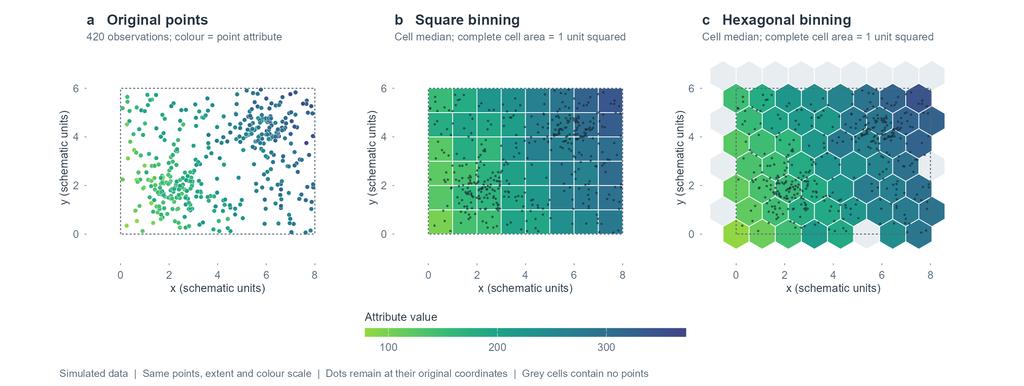

同一批模拟点：原始点、等面积方格与六边形分箱

**读图。** 同一批模拟点分别汇总到等面积方格与六边形，整体高低值位置相近，边界附近的混合和局部细节有所不同。聚合得到区域代表值，也压缩了格内差异。

##### 为什么选六边形？方格可以吗？

| 比较项 | 正六边形 | 正方形 |
| --- | --- | --- |
| 完整密铺内部的邻居 | 6 个共边邻居，中心距离相等。 | 4 个共边邻居；加入角邻居后为 8 个，角邻居距离是边邻居的 $\sqrt{2}$ 倍。 |
| 形状与数据衔接 | 同面积时更紧凑，适合比较六个方向的邻域，仍有固定方向。 | 便于与栅格像元、行列索引衔接，也可旋转。 |
| 本例需要核对 | 少样本格退出后，邻居可能不足 6 个；实测 Queen 与 Rook 列表相同。 | Queen 与 Rook 通常不同，需随几何重新定义。 |

几何解释见 [Esri：Why hexagons?](https://pro.arcgis.com/en/pro-app/3.4/tool-reference/spatial-statistics/h-whyhexagons.htm)。两种形状均需检查面积、起点和边缘。

**等面积比较的参数。** 当 $A=0.10\text{ km}^2$ 时，方格边长 $\sqrt{A}\approx316.23$ m；正六边形边长 $\sqrt{2A/(3\sqrt{3})}\approx196.19$ m，对边距离约 339.81 m。`st_make_grid()` 的六边形 `cellsize` 指对边距离；只切换 `square` 而保留原 `cellsize` 会改变面积。长度须换成投影单位，本例 EPSG:2263 使用美国测量英尺。见 [`st_make_grid()` 文档](https://r-spatial.github.io/sf/reference/st_make_grid.html)。

**选学进阶 · Uber H3 的层级网格与索引压缩**

[Uber 的 H3](https://www.uber.com/us/en/blog/h3/) 是以六边形为主的全球层级空间索引 （hierarchical geospatial index）。单元有唯一编号，可查询父格、子格和邻居；分辨率 0–15，数值越大，单元越小。

**按密度调整大小。** 可先在同一细层级编码所有点，再设置点数阈值：过密区域继续细分，稀疏区域沿父索引合并。最终每点只归入一个组，各组重新计算统计量。规则需另行设定；[H3 已答讨论](https://github.com/uber/h3/discussions/737)与[自适应网格交互示例](https://observablehq.com/@nrabinowitz/h3-adaptive-grid)展示了实现思路。

**索引压缩。** [`compactCells()`](https://h3geo.org/docs/api/hierarchy/#compactcells) 将齐全的同层子格集合递归换成父格；它读取索引集合，不读取房源点数。下图展示这一操作。

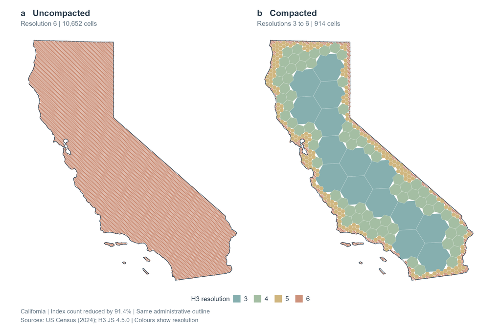

加州 H3 索引：统一细分辨率与压缩后的混合分辨率表示

加州的 **10,652 个分辨率 6 索引**压缩为 **914 个混合层级索引**，数量减少约 **91.4%**；展开回分辨率 6 后，索引集合完全恢复。内部容易凑齐完整子格组，边缘较多细格保留。颜色表示分辨率，格的大小由子格集合是否齐全决定，与人口或房源密度无关。

图按 [Uber 原文](https://www.uber.com/us/en/blog/h3/)与 [H3 官方索引说明](https://h3geo.org/docs/highlights/indexing/)的思路独立计算；行政轮廓采用 [U.S. Census Bureau 制图边界](https://www.census.gov/geographies/mapping-files/time-series/geo/cartographic-boundary.html)。

**使用边界。** 父子关系在索引上精确，原生几何仅近似嵌套，多层级绘图可出现间隙或重叠，见[边界交互示例](https://observablehq.com/@nrabinowitz/h3-hierarchical-non-containment)。每个分辨率还包含 12 个五边形，同级面积并非处处相同；[尺度表](https://h3geo.org/docs/core-library/restable/)中的分辨率 9 平均面积约 0.105 km²，只可作为尺度参照。

**应用阅读。** Uber 原文介绍出行供需；[Volkswagen／NVIDIA 案例](https://developer.nvidia.com/blog/accelerating-volkswagen-connected-car-data-pipelines-100x-faster-with-nvidia-rapids/)以每批约 2,500 条位置记录为计算约束，逐级细分过密组。若用混合层级格比较报价，还需记录实际覆盖与点数，重新定义邻居。本例仍保留固定面积的 `sf` 平面六边形。

#### **3.3 研究设置的不足与改进**

##### 样本与报价口径

统一 30 夜后，实际入住日期、房型、可住人数和折扣仍有差异。三个批次还存在上下架及价格缺失。可先按批次、房型检查缺失比例和报价分布，再比较相近住宿产品。

同坐标合并改变了观测权重：同一公开坐标可能包含多套房源，同一房源的位置也需跨期核对。按房源 ID 汇总与按坐标汇总可作为一项对照；未出现的批次保留为未观测状态。

##### 价格筛选与空间覆盖

P5–P95 聚焦常见报价，也改变格内组成和达到点数门槛的区域。**比较筛选方案时，要同时检查报价变化与覆盖变化。** 下表的记录数、坐标数来自各方案筛选后的全部样本；“各自有效格的 I”使用本方案达到点数门槛的格，最后一列固定共同的 363 格及同一 Queen 权重。

| 30 夜报价方案 | 记录数 | 坐标数 | 有效格 | 各自有效格的 I | 共同 363 格的 I |
| --- | --- | --- | --- | --- | --- |
| 完整正报价 | 19,061 | 8,478 | 379 | 0.430 | 0.571 |
| 对数价格双侧 1.5×IQR：30.08–1,301.29 美元／夜 | 18,676 | 8,312 | 373 | 0.583 | 0.575 |
| **P5–P95：59.13–782.95 美元／夜** | **17,209** | **7,792** | **363** | **0.583** | **0.583** |

固定覆盖后，三方案的 I 差距缩小，均保留整体正向关联。各方案局部 HH／LL 的稳定性尚未比较。主方案排除低端 900 条、高端 952 条，保留约 90.28%；端点并列价格使比例不必恰为 90%。区间外报价仍可能有效，筛选口径应与研究对象对应。

##### 空间聚合与尺度选择：当前模式是否稳定？

本例采用 **0.10 km² 六边形、每格至少 5 个不同坐标**。这项选择同时影响局部细节、格内数据量及有效覆盖，需要结合敏感性分析讨论。

**15 分钟城市：生活圈与计算单元**

15 分钟城市强调居民通过约 15 分钟步行或骑行获得日常服务。[Moreno 等（2021）](https://doi.org/10.3390/smartcities4010006)从密度、邻近、多样性与数字化讨论这一规划框架。它为本例提供邻里尺度的观察视角。

[Bruno 等（2024）](https://doi.org/10.1038/s44284-024-00119-4)的[作者公开稿方法部分](https://arxiv.org/html/2408.03794v1#S3.SS2)采用**边长 200 m**的六边形，再用 OSRM 计算到设施的路网时间。其计算单元与本例约 196 m 的边长接近，为细尺度选择提供了研究实现参照。

**本例的 0.10 km² 承载报价汇总；15 分钟服务范围取决于路网、出行方式和设施位置。** 时间目标不能直接推导固定面积，面积是否适合当前数据仍需检验。

**先看一次聚合隐藏了什么。** 两个真实格的中位价相近，内部报价却很不同：

| 检查项 | 格 419 | 格 795 |
| --- | --- | --- |
| 中位报价（美元／夜） | 235.60 | 241.18 |
| 不同公开坐标数 n | 44 | 8 |
| 中间一半坐标报价所在区间 Q1–Q3（美元／夜） | 211.75–259.77 | 152.15–600.87 |

IQR 是上述区间的宽度 $Q_3-Q_1$，两格分别为 **48.02** 与 **448.73 美元**。它衡量格内离散程度；n 表示汇总所依据的位置数量，两者共同补充中位价图。

**查看当前网格的诊断图 · 两格分布与全岛 n／IQR**

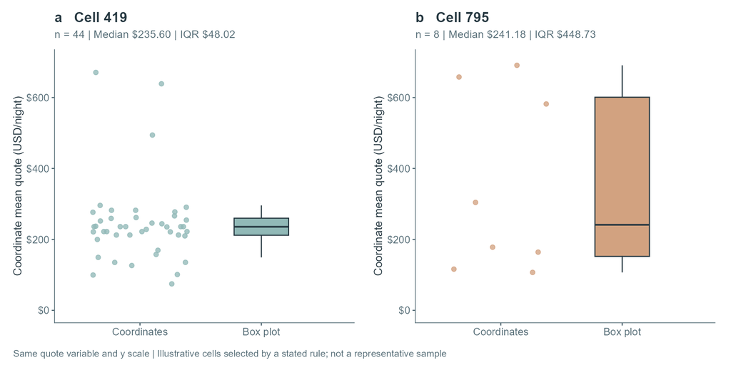

两个中位报价相近的真实六边形：坐标报价与箱线图

两图纵轴一致，每点是一个坐标的最终均价。选例先要求 n≥8、IQR≥20 美元，再从中位价相对差≤5%、坐标数之比≥2 的候选对中选取 IQR 比值最大的一对，用于展示分布差异。逐一删去一个坐标后，中位价最大绝对变化为 0.40／63.13 美元；这描述当前观测的敏感程度，不作置信区间解释。

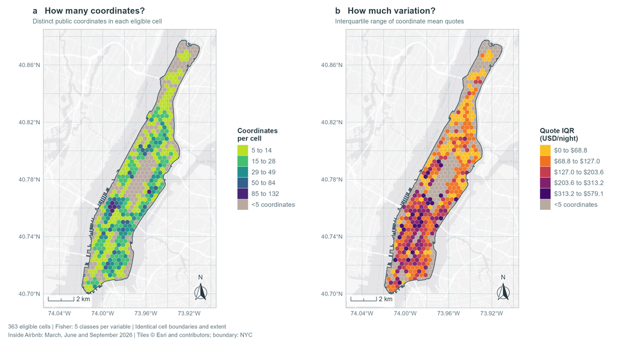

当前0.10 km²网格的样本支持：不同坐标数与格内报价IQR（分别采用五级Fisher）

363 个有效格的 n 为 **5–132**，中位数 **16**；格内 IQR 的中位数为 **109.29 美元／夜**。两图分别采用五级 Fisher 显示点数和 IQR，再与中位价、LISA对读。统计均基于最终坐标均价，分位点用 `type = 7`；IQR 及点数不等同于中位数的精度，至少 5 点只规定纳入资格。定义见 [R IQR 文档](https://stat.ethz.ch/R-manual/R-devel/library/stats/html/IQR.html)，重抽样推断可选读 [Bootstrap 教程](https://rafalab.dfci.harvard.edu/dsbook-part-2/inference/bootstrap.html)。

**再改变空间划分，检验 MAUP。** 上述图检查当前固定网格；改变单元面积或边界后重算，才是在比较尺度效应与分区效应。可回看导论及 [NCRM 的 MAUP 教学案例](https://www.restore.ac.uk/geo-refer/91023cwors00y00000000.php)。

**起步方案：先做三组有区分度的检查**（尚未运行）。

| 改变什么？ | 怎样设置？ | 重点比较什么？ |
| --- | --- | --- |
| **面积：尺度效应** | 0.05、0.10、0.20 km²；固定价格口径、网格方向与基准起点，并记录参数。 | 区域中位价、有效覆盖及 HH／LL 片区的位置与连片程度。 |
| **起点：分区效应** | 固定 0.10 km²，沿投影坐标方向平移半个网格间距。 | 同一批点重新归格后，局部边界和中位价如何变化。 |
| **点数门槛：样本支持** | 固定网格，比较至少 3、5、10 个坐标。 | 哪些区域失去覆盖，统计量与局部类型是否随之改变。 |

方格对照可沿用等面积参数另设一组。点数门槛改变的是样本纳入，需与改变空间单元的 MAUP 检查分开记录。

1. **固定输入**：沿用主方案的价格范围与坐标均价，每次只改变一项设置。
2. **完整重算**：重新归格、聚合、筛选有效格，再建立对应权重并运行全局／局部检验。
3. **并列判断**：使用一致的底图、价格显示断点与 LISA 色盘，同时报告覆盖、邻居和连通部分。格的几何改变时按地理区域对照；固定格网比较价格筛选或点数门槛时，可另取共同有效格及同一权重。

敏感性分析关注主要发现是否持续出现，也记录发生改变的位置与原因；不以统计量增大或显著格增多作为参数选择目标。

##### 对北部 LL 的解释还缺哪些资料？

北部连续 LL 提供了局部低报价的线索。可先按房型重复坐标合并和网格聚合，检查相似住宿产品之间是否仍有南北差异；一个公开坐标可能包含不同房型，应在各房型内部重新汇总。

北部社区资料提供历史、人口及住房负担背景。若要检验社区条件能否解释报价差异，需要匹配边界与年份，再纳入房型、入住日期和区位信息。当前图件完成的是空间分异描述。

#### **3.4 地理学方法拓展与阅读**

##### 聚合之后，怎样定义“周围”？

| 权重方式 | 表达什么关系？ | 检查重点 |
| --- | --- | --- |
| 接壤邻接 | Queen 包括共边或共顶点；Rook 要求共边。 | 实际邻居列表、边缘单元。 |
| 距离阈值 | 指定距离内纳为邻居。 | 距离依据、单位、无邻居格。 |
| k 最近邻 | 每格选最近的 k 个其他格。 | 稀疏区长连线与关系是否对称。 |

本例有 **3 个连通部分、没有孤立格**。连通部分由邻接路径划分，与 HH／LL 类型不同；更换权重后需报告这种结构。距离候选可试 500／1,000 m 或 k=4／6／8，须说明使用格心距离，并把米换成 EPSG:2263 的美国测量英尺。主岛边界限定了邻域，其他行政区的报价未纳入。

**邻接图如何变成矩阵？**

设有四个依次相邻的分析单元 $1\leftrightarrow2\leftrightarrow3\leftrightarrow4$，各行、各列均按 1、2、3、4 排列。这个教学例子演示权重计算。

二元邻接矩阵 $B$ 记录邻居关系，相邻为 1、不相邻为 0，对角线为 0：

$$B=\begin{pmatrix}
0&1&0&0\\
1&0&1&0\\
0&1&0&1\\
0&0&1&0
\end{pmatrix}.$$

第 $i$ 行有 $k_i=\sum_j b_{ij}$ 个邻居。对有邻居的行，行标准化令 $w_{ij}=b_{ij}/k_i$，得到

$$W=\begin{pmatrix}
0&1&0&0\\
1/2&0&1/2&0\\
0&1/2&0&1/2\\
0&0&1&0
\end{pmatrix}.$$

假定四格报价为 $x=(100,200,300,400)^\mathsf{T}$ 美元／夜，则 $Wx=(200,200,300,300)^\mathsf{T}$。例如第 2 格周围是第 1、3 格，两者的平均为 $(100+300)/2=200$。将 $x$ 换成标准化报价 $z$，得到的就是 Moran 散点图纵轴 $Wz$。

这个矩阵还说明：邻居关系可以对称，行标准化后的数值权重却未必对称。第 1 格只有一个邻居，给第 2 格的权重为 1；第 2 格有两个邻居，给第 1 格的权重为 $1/2$。因此，检查邻接与检查权重数值要分开进行。矩阵行列的 ID 顺序必须与价格向量一致。

选读 [Paula Moraga 的空间邻近矩阵教材](https://www.paulamoraga.com/book-spatial/spatial-neighborhood-matrices.html)；定义和实现见 [GeoDa 接壤权重教程](https://geodacenter.github.io/workbook/4a_contig_weights/lab4a.html)及 [spdep 的 `nb2listw()` 文档](https://r-spatial.github.io/spdep/reference/nb2listw.html)。

`zero.policy = TRUE` 允许无邻居格的空间滞后按零处理，本例没有此类格。全局置换在全部有效格间重排；若改为连通部分内部重排，原假设也随之改变。见 [spdep 连通部分说明](https://r-spatial.github.io/spdep/articles/subgraphs.html)。

##### 数值变换与显示分级会怎样影响结果？

固定主方案 363 格、顺序及同一 Queen 权重，已有诊断如下：

| 分析变量 | Moran’s I | 含义 |
| --- | --- | --- |
| 格内中位报价 x（美元／夜） | 0.583 | 正式方案，保留绝对金额。 |
| 标准化 $(x-\bar{x})/s_x$ | 0.583 | 统一平移、缩放不改变 I。 |
| 已有格内中位报价的自然对数 $\log(x)$ | 0.677 | 压缩高端绝对差距，改变各格的统计贡献。 |

取对数后的较高 I 不代表方案更正确，应按绝对金额或相对差异的研究目标选择。这里没有重新筛选或聚合，也未重算对数方案的 LISA。**Fisher 分级与对数色标只改变显示**；检验输入原数值时，I 保持原结果。对数价格 IQR 筛选则改变纳入记录，见价格方案比较。

##### 局部检验与区域解释各有什么边界？

363 格对应一组局部检验，BH 调整关注被判为显著结果中的错误发现比例的期望，即错误发现率 （false discovery rate, FDR）。保证依赖有效 p 值及相应依赖条件。后续可固定其他设置，比较更严格阈值或适用于一般依赖结构的 BY 调整；方法见 [`p.adjust()`](https://stat.ethz.ch/R-manual/R-devel/library/stats/html/p.adjust.html)。

**生态谬误。** 即使将来发现低报价格集中在贫困率较高的社区，也只能先描述区域关联；判断低收入居民或房东是否提供更低报价，需要相应个体资料。可阅读 [Robinson（1950）](https://doi.org/10.2307/2087176)。

**解释模型之前，还可检查两件事。** 一是按格心距离查看[空间相关图](https://geodacenter.github.io/workbook/5a_global_auto/lab5a.html#spatial-correlogram)，同时列出距离区间的格对数量，观察关联与南北趋势。二是考虑[公开位置约 0–150 m 的匿名偏移](https://insideairbnb.com/data-assumptions/)，按明确规则做位置扰动，记录归格和覆盖变化。两项尚未运行；扰动是情景比较，不能还原真实位置。若后续拟合模型，剩余关联应使用适合残差的检验，如 [`lm.morantest()`](https://r-spatial.github.io/spdep/reference/lm.morantest.html)。

##### 拓展阅读：从概念到研究实施

- **15 分钟城市的概念。** [Moreno 等（2021），Smart Cities](https://doi.org/10.3390/smartcities4010006)，可读[出版社全文](https://mdpi-res.com/d_attachment/smartcities/smartcities-04-00006/article_deploy/smartcities-04-00006.pdf)第 5–6 节：时间预算怎样联系邻近、多样性与出行方式？
- **细尺度单元与可达性。** [Bruno 等（2024），Nature Cities](https://doi.org/10.1038/s44284-024-00119-4)及[作者公开稿](https://arxiv.org/html/2408.03794v1)：先看图 1，再读方法 3.2–3.3，区分网格、路网时间及人口加权。
- **从研究到规划。** [C40：Green and Thriving Neighbourhoods](https://www.c40.org/what-we-do/scaling-up-climate-action/urban-planning-design/green-and-thriving-neighbourhoods/)：邻近规划怎样落实到街区服务与公共空间？
- **空间统计的后续问题。** [Spatial Data Science](https://r-spatial.org/book/15-Measures.html)讨论趋势、遗漏变量与自相关；[GeoDa 教程](https://geodacenter.github.io/workbook/5a_global_auto/lab5a.html)连接全局、局部指标与地图。
- **Airbnb 与城市变化。** [Wachsmuth 与 Weisler（2018）](https://doi.org/10.1177/0308518X18778038)联系纽约租差与绅士化；[Barron、Kung 与 Proserpio（2021）](https://doi.org/10.1287/mksc.2020.1227)帮助理解研究住房价格和租金影响还需要哪些数据与识别设计。

**© 华东师范大学 社会发展学院 人口研究所** | [**DAWN 研究组**](https://dawn-ecnu.github.io) | yzliu@soci.ecnu.edu.cn

课程负责人：刘贇喆 本章作者：刘贇喆 | 敖漪宇

最后更新：2026年10月20日 构建环境：R version 4.6.1 (2026-06-24 ucrt)

[CC BY-NC-SA 4.0](https://creativecommons.org/licenses/by-nc-sa/4.0/deed.zh) 回到顶部

## **4.0 专题研究 2**

### **4.0 专题研究 2: 社交媒体点**

#### **专题研究 2: 上海六区微博记录空间分析**

##### **分析导航**

**微博记录热点与交通设施的空间对比**

**从记录分布到高密度区，再到设施距离比较**

本节选取黄浦、徐汇、长宁、静安、杨浦与闵行六区，使用微博记录与公共交通 POI，依次完成范围筛选、核密度估计、高密度区提取和设施邻近性比较。

点击下方卡片，快速跳转至相应模块：

**© 华东师范大学 社会发展学院 人口研究所** | [**DAWN 研究组**](https://dawn-ecnu.github.io) | yzliu@soci.ecnu.edu.cn

课程负责人：刘贇喆 本章作者：刘贇喆 | 敖漪宇

最后更新：2026年10月20日 构建环境：R version 4.6.1 (2026-06-24 ucrt)

[CC BY-NC-SA 4.0](https://creativecommons.org/licenses/by-nc-sa/4.0/deed.zh) 回到顶部

##### 课题与目标

###### **4.1 研究课题与分析目标**

**示例课题**

上海六区微博记录热点与公共交通设施邻近性比较

公共交通设施提供出行接入点，地理标记微博留下部分平台活动的位置线索。本课题结合两类点数据，比较六区微博记录高密度区内外的设施距离，建立从**原始点、KDE密度表面到AOI内外比较**的分析流程。

累计热点是否来自日常活动、短期事件或重复发帖，以及相近的设施距离是否对应相近的出行条件，需要时间分段、路网与人群资料进一步检验。

**三个递进问题**

1. **热点在哪里？** 2020–2025年汇总的微博记录，在各区主要集中于哪些位置？
2. **设施有多近？** 各区高密度区内外的记录位置，到最近公交站、地铁站的距离分布有何差异？
3. **比较是否稳定？** 改变带宽、密度阈值或时间窗口后，热点位置和距离差异是否保持？

前两问对应本节的主要流程，第三问用于后续验证。AOI内设施距离更短、更长，或差异不明确，均按实际结果报告。

**从记录集聚到城市活力**

**记录集聚**

描述样本记录在空间上的集中程度。一条记录对应一次被纳入样本的发布或签到行为，**同一用户可以留下多条记录**。

**城市活力**

涉及活动的强度、持续性、多样性及时间变化，不同研究的定义和指标有所区别（[Liu et al., 2023](https://doi.org/10.1007/s11442-023-2139-1)）。讨论活力还需结合独立用户、活动类型、人口或出行资料。

**累计热点的持续性需另行检验。** 六年汇总图叠加了日常活动与短时事件。按月、季节或年份重复分析，才能判断哪些高值区持续出现。

**研究延伸：怎样从设施邻近性走向可达性与空间公平？**

| 研究层次 | 可以进一步提出的问题 | 需要补充的资料 |
| --- | --- | --- |
| 平台活动与时空热点 | 热点是否在工作日、周末、昼夜或不同年份反复出现？活动类型是否一致？ | 可比较的时间窗口、匿名用户、活动类型及独立资料。 |
| 交通可达性 | 从活动地点出发，步行多久可到站，乘车后能到达哪些就业、医疗或教育机会？ | 路网、站点入口、时刻表、换乘规则与目的地。 |
| 空间公平 | 哪些人群或地区的出行需求较高，却获得较少的服务机会？ | 居民分布、出行需求、年龄或收入等人群资料，以及明确的公平评价标准。 |

设施距离短，可以减少接近站点的空间阻隔；实际使用仍受入口、班次、票价和出行能力等条件影响（[Cooke et al., 2022](https://doi.org/10.3389/frsc.2022.811049)）。空间公平进一步追问，交通服务的机会与负担如何分配，哪些人群仍受到使用条件的限制（[Verlinghieri & Schwanen, 2020](https://doi.org/10.1016/j.jtrangeo.2020.102798)）。这需要把**服务供给与人群需求**放在一起比较；仅凭微博点或站点数量，无法判断谁获得了更充分的服务。

已有研究利用地理标记社交媒体，按时段、活动类型和人口特征分析城市活动的时空差异，可作为本例分时分析的设计参考（[Niu & Silva, 2023](https://doi.org/10.1016/j.compenvurbsys.2022.101934)）。本例的匿名样本没有可核实的人口属性，不能直接从发帖内容推断用户的年龄或收入；若需比较人群，应另补充合适资料。

上海购物中心的一项研究整合抖音、小红书、微博、大众点评和百度指数，从**关注、活动、体验**三个层面评价商业空间活力（[Zhang et al., 2025](https://doi.org/10.3390/land14040697)）。它为多源指标设计提供了一个本地范例：网络关注、位置记录和使用体验应分别测量，再考察它们是否一致。

活动与站点相邻也可能有多种解释：交通条件吸引活动，商业与就业场所同时吸引两者，或特定地点的发帖习惯造成记录集中。检验这些解释，可逐步加入用地、就业、场所类型与分时段数据；判断交通变化的作用，则需要设施变化前后的比较及合适的对照。

**分析范围**：2020–2025年上海微博**4%随机样本**，共215,968条记录，全部72个月均有记录；地图汇总整个时期。实际出行可达性与居民服务公平性留待补充资料后研究。

**© 华东师范大学 社会发展学院 人口研究所** | [**DAWN 研究组**](https://dawn-ecnu.github.io) | yzliu@soci.ecnu.edu.cn

课程负责人：刘贇喆 本章作者：刘贇喆 | 敖漪宇

最后更新：2026年10月20日 构建环境：R version 4.6.1 (2026-06-24 ucrt)

[CC BY-NC-SA 4.0](https://creativecommons.org/licenses/by-nc-sa/4.0/deed.zh) 回到顶部

##### 研究区域与数据

###### **4.2 研究区域与数据获取**

本例选择**黄浦、徐汇、长宁、静安、杨浦**五个中心城区，并保留**闵行**作为原案例的对照。各区面积和场所结构不同，适合比较高密度区的位置、形态及其交通设施邻近性。

| 数据 | 本例的作用 | 读取与解释口径 |
| --- | --- | --- |
| 微博 4% 随机样本 | 识别记录分布与高密度区。 | 2020–2025 年，215,968 条；WGS84坐标，保留样本内匿名用户编号。 |
| 公交站、地铁站 POI | 计算到最近设施的直线距离。 | 按文件声明读取坐标；设施搜索保留上海全市范围。 |
| 2025 年行政区划边界 | 确定空间筛选与展示范围。 | 使用更新的上海16区边界，专题2与旧练习边界文件分开保存。 |

**样本怎样得到？** 数据提供文件共 5,399,200 条记录。先对全部记录进行无放回简单随机抽样，固定种子为 `20261016`，抽出精确的4%；抽样前不按年份或地区筛选，也不去重。抽样后再按行政边界筛选研究范围。

课程样本只保留匿名用户编号、发布时间、经度、纬度、年份和月份。匿名编号仅用于识别本样本中的重复用户，不与旧版编号连接。样本与抽样说明位于 [Example_data 数据仓库](https://github.com/DAWN-ECNU/Example_data)；下方代码使用本地 `data/` 文件，便于离线复现。

**4% 是记录的比例**。随机抽样可减少课堂计算量，仍保留原始资料的平台覆盖与发帖选择特征。它不代表抽取了4%的居民或4%的独立访客。不同年份的记录量也有差异，跨年比较需进一步核对采集与平台使用条件（[Petutschnig et al., 2021](https://doi.org/10.3390/ijgi10050323)）。

**运行前：核对文件与目录**

工作目录可设为课程根目录或第5章目录。下列路径均相对于**第5章目录**；代码开关位于图形下方，按编号运行，后续模块沿用前一步对象。

**`data/weibo_sample_4pct.csv`**

2020–2025年微博4%随机样本

**`data/shanghai_boundary_2025.geojson`**

上海16区行政边界

**`data/公交站.geojson`**

全市公交设施位置

**`data/地铁站.geojson`**

全市地铁设施位置

**`figures/weibo-multidistrict/amap_corrected_basemap.R`**

高德瓦片坐标匹配辅助函数

**运行顺序**：依赖与参数 → 数据读取 → 底图与视野 → 地图版式 → 研究区总览。课程已使用 `tidyverse`，其中的读取、整理和绘图包无需重复加载；本节另加载 `sf` 与 `patchwork`，其他包通过 `包名::函数名()` 调用。首次配置时在 Console 补装缺少的包。

**字段先规范**：用 `rename()` 将来源表头转为英文 `snake_case`，后续使用 `user_id`、`posted_at`、`longitude`、`latitude`、`year` 和 `month`。原始CSV保留来源格式，中文用于图题、图例与表头。

**计算与显示分别设置坐标**：WGS84经纬度记录位置；**KDE、面积与距离使用UTM 51N米制坐标**，面积再换算为平方千米。地图采用Web Mercator显示，使真北朝上、经纬网横平竖直；显示投影不参与分析计算。

**底图与坐标：高德瓦片怎样匹配？**

底图默认使用[高德地图](https://www.amap.com/)，提供道路、水系与地名背景。将 `basemap_provider <- "amap"` 改为 `"esri"`，可切换到保留的Esri浅灰底图；两个来源的缓存分别保存。首次绘图需要联网，下载后的瓦片保存在 `cache/map_tiles/`。

高德瓦片采用GCJ-02坐标。辅助函数先对底图像素作近似坐标匹配，再将底图与矢量图层放入共同的显示投影。分析数据仍按WGS84读取、在UTM下计算。**底图只提供地理背景，不用于测量距离或判定行政归属。**

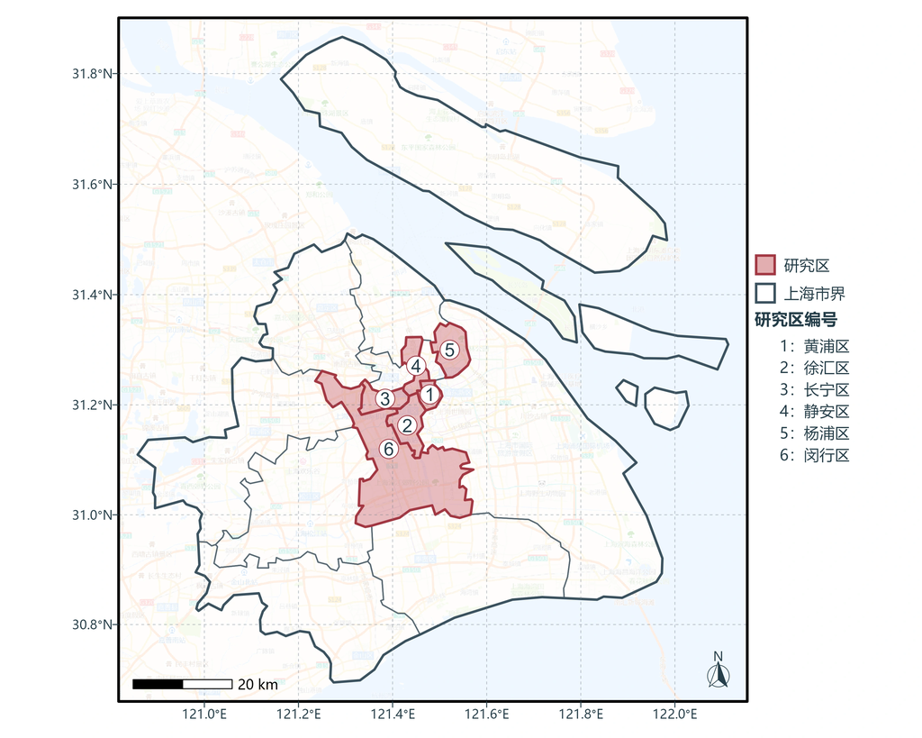

上海全市行政边界与六个研究区。红色半透明高亮研究范围；真北朝上，经纬网横平竖直，1–6编号与后续分区图一致。

**底图来源**：底图：高德地图（style 7）；仅对底图作坐标匹配重采样

**1 · 依赖包、路径与共同参数**

```r
# 模块 1 · 依赖包、路径与共同参数 ----------------------
# 先配置运行环境；本模块尚不读取或筛选记录。

# tidyverse 已提供 readr、dplyr、tidyr 和 ggplot2，无需再逐一加载。
# 首次使用时在 Console 安装；课程环境已有 tidyverse 时，只补装其余包。
# install.packages("tidyverse")
# install.packages(c("sf", "patchwork", "MASS", "terra", "ggspatial",
#                    "ragg", "jsonlite", "isoband", "rosm", "png", "digest"))
library(tidyverse)  # 数据读取、整理与 ggplot2 绘图
library(sf)         # 空间对象、投影转换与距离计算
library(patchwork)  # 多面板排版

# 其余包通过“包名::函数名()”调用；这里只检查是否安装，不重复 library()。

needed_packages <- c(
  "MASS", "terra", "ggspatial", "ragg", "jsonlite", "isoband",
  "rosm", "png", "digest"
)
missing_packages <- needed_packages[
  !vapply(needed_packages, requireNamespace, logical(1), quietly = TRUE)
]
if (length(missing_packages)) {
  stop("请先安装：", paste(missing_packages, collapse = ", "))
}

# 路径：兼容课程根目录与第5章目录。
chapter_dir <- if (file.exists("data/weibo_sample_4pct.csv")) "." else "第5章"
chapter_dir <- normalizePath(chapter_dir, winslash = "/", mustWork = TRUE)
data_dir <- file.path(chapter_dir, "data")
image_dir <- file.path(chapter_dir, "images")
result_dir <- file.path(chapter_dir, "figures", "weibo-multidistrict", "results")
tile_cache_dir <- file.path(chapter_dir, "cache", "map_tiles")
dir.create(result_dir, recursive = TRUE, showWarnings = FALSE)
dir.create(tile_cache_dir, recursive = TRUE, showWarnings = FALSE)

# 区名顺序在地图、表格和距离图中保持一致。保留闵行作为原案例参照。
district_order <- c("黄浦区", "徐汇区", "长宁区", "静安区", "杨浦区", "闵行区")
# 分析参数：米制坐标用于密度、面积和距离计算。
target_crs <- 32651       # UTM 51N，坐标单位为米；WGS84经纬度的单位是度。
display_crs <- 3857L     # 仅用于地图显示：真北朝上，经线竖直、纬线水平。
cell_m <- 75             # 评价网格边长；自动带宽较小的城区也需保留足够绘图细节。
aoi_quantile <- 0.95     # 每个区分别按区内密度网格的第95百分位数提取AOI。

# 显示参数：字体、配色与底图来源。
font_family <- "Microsoft YaHei"
ink <- "#253e49"
point_colour <- "#245d73"
study_colour <- "#C65B61"
boundary_colour <- "#496672"
aoi_colour <- "#00FF00"
# 密度图采用 Inferno 与透明度叠加，AOI 使用绿色虚线；这些设置只影响显示。
# 修改这一个选项即可切换底图，两个来源的缓存分别保留。
basemap_provider <- "amap"       # 可选 "amap" 或 "esri"
stopifnot(basemap_provider %in% c("amap", "esri"))
```

**2 · 读取数据与规范字段**

```r
# 模块 2 · 读取数据与规范字段 ----------------------
# 使用上一步的 data_dir 和 target_crs；读取微博、区界与两类交通 POI。

# 1) 微博记录：先读取，再将来源字段改为英文 snake_case。
# 匿名ID只标识本样本内的同一用户；一条记录不等于一名独立访客。
# 原始CSV保留来源表头；进入分析后立即统一为英文snake_case。
# 六列依次为字符、字符、数值、数值、整数、整数，不将匿名编号读成数字。
source_columns <- c(
  user_id = "匿名用户ID",
  posted_at = "发布时间",
  longitude = "经度",
  latitude = "纬度",
  year = "年份",
  month = "月份"
)
weibo_raw <- read_csv(
  file.path(data_dir, "weibo_sample_4pct.csv"),
  col_types = "ccddii",
  show_col_types = FALSE
) %>%
  rename(all_of(source_columns))
stopifnot(nrow(problems(weibo_raw)) == 0L)

# 2) 行政区界：投影转换、几何修复与研究区排序。
shanghai_districts <- st_read(
  file.path(data_dir, "shanghai_boundary_2025.geojson"),
  quiet = TRUE
) %>%
  st_transform(target_crs) %>%
  st_make_valid()

study_districts <- shanghai_districts %>%
  filter(district_name %in% district_order) %>%
  mutate(district_name = factor(district_name, levels = district_order)) %>%
  arrange(district_name)
stopifnot(
  nrow(shanghai_districts) == 16L,
  nrow(study_districts) == 6L,
  all(st_is_valid(study_districts)),
  !any(st_is_empty(study_districts))
)

# 3) 交通 POI：保留全市范围，供后续最近设施匹配使用。
# 保留文件声明的CRS，再进行转换；不靠st_set_crs()掩盖来源坐标不一致的问题。
poi_bus <- st_read(file.path(data_dir, "公交站.geojson"), quiet = TRUE)
poi_subway <- st_read(file.path(data_dir, "地铁站.geojson"), quiet = TRUE)
stopifnot(!is.na(st_crs(poi_bus)), !is.na(st_crs(poi_subway)))
bus_proj <- st_transform(poi_bus, target_crs)
subway_proj <- st_transform(poi_subway, target_crs)
```

**3 · 底图、导出与分区视野**

```r
# 模块 3 · 底图、导出与分区视野 ----------------------
# 使用区界与共同参数；定义可重复调用的函数，不改变分析几何。

# 1) 输出设备与显示对象。
# 通过ragg输出中文PNG，PDF使用Cairo；不需要showtext把文字转成大量路径。
if (requireNamespace("showtext", quietly = TRUE)) showtext::showtext_auto(FALSE)
export_board <- function(plot, name, width = 11.2, height = 16.2) {
  ggsave(
    file.path(image_dir, paste0(name, ".png")),
    plot,
    device = ragg::agg_png,
    width = width,
    height = height,
    units = "in",
    dpi = 300,
    bg = "white"
  )
  ggsave(
    file.path(result_dir, paste0(name, ".pdf")),
    plot,
    device = grDevices::cairo_pdf,
    width = width,
    height = height,
    units = "in",
    family = font_family,
    bg = "white"
  )
}

show_course_plot <- function(plot) {
  if (interactive() || isTRUE(getOption("knitr.in.progress"))) print(plot)
}

# 分析继续使用UTM 51N；显示几何另外转换为Web Mercator，不修改分析对象。
# Web Mercator中的真北朝向正上方；面积和距离仍由UTM分析几何计算。
shanghai_display <- st_transform(shanghai_districts, display_crs)
study_display <- st_transform(study_districts, display_crs) %>%
  mutate(district_id = factor(seq_len(n()), levels = seq_along(district_order)))

# 2) 底图：读取匹配函数，配置来源与缓存。
# 瓦片为Web Mercator；高德瓦片还需处理GCJ-02与WGS84之间的位置差异。
# 底图只提供道路和水系背景，不参与点筛选、密度计算或距离测量。
# 首次绘制需要联网，下载后保存在章节cache/map_tiles，后续可复用。
# 高德瓦片使用GCJ-02，先在底图层反向采样至WGS84 / Web Mercator视野。
# 只调整背景图像，研究点、区界、KDE和距离计算的坐标均保持不变。
source(
  file.path(chapter_dir, "figures", "weibo-multidistrict", "amap_corrected_basemap.R"),
  encoding = "UTF-8"
)
esri_tile_url <- paste0(
  "https://services.arcgisonline.com/ArcGIS/rest/services/Canvas/",
  "World_Light_Gray_Base/MapServer/tile/${z}/${y}/${x}"
)
esri_credit <- paste0(
  "Tiles: Esri, HERE, Garmin, (c) OpenStreetMap contributors, ",
  "and the GIS user community"
)
amap_credit <- "底图：高德地图（style 7）；仅对底图作坐标匹配重采样"
basemap_credit <- if (basemap_provider == "amap") amap_credit else esri_credit
rosm::register_tile_source(
  weibo_light_gray = rosm::as.tile_source(
    esri_tile_url,
    extension = "jpg",
    max_zoom = 13,
    attribution = esri_credit
  )
)
basemap_layer <- function(window, zoom, alpha = 0.4, output_width = 1600L) {
  if (basemap_provider == "amap") {
    background <- amap_corrected_raster(
      window = window,
      zoom = zoom,
      cache_dir = tile_cache_dir,
      target_crs = display_crs,
      output_width = output_width
    )
    return(amap_corrected_layer(background, alpha = alpha))
  }
  ggspatial::annotation_map_tile(
    type = "weibo_light_gray",
    zoom = min(zoom, 13L),
    alpha = alpha,
    cachedir = tile_cache_dir,
    quiet = TRUE
  )
}

# 瓦片层级随显示视野选择，避免小区沿用低层级时把地名放得过大。
# 这是底图细节参数，与KDE的75米网格和自动带宽无关。
choose_tile_zoom <- function(window, target_pixels = 1600) {
  span <- max(
    window["xmax"] - window["xmin"],
    window["ymax"] - window["ymin"]
  )
  zoom <- round(log2(40075016.69 * target_pixels / (256 * span)))
  as.integer(max(10, min(16, zoom)))
}

# 3) 视野与经纬网：同一区在不同地图中保持共同范围。
# 用独立sf线几何画经纬网，避免网格被研究区填色或KDE面盖住。
map_graticule <- function(window) {
  extent <- st_as_sfc(st_bbox(
    setNames(
      unname(window[c("xmin", "ymin", "xmax", "ymax")]),
      c("xmin", "ymin", "xmax", "ymax")
    ),
    crs = st_crs(display_crs)
  ))
  st_graticule(extent, crs = st_crs(display_crs), datum = st_crs(4326))
}

# 每区独立缩放以便看清内部结构；同一区在点图/KDE/AOI中使用相同视野。
map_windows <- lapply(seq_len(nrow(study_display)), function(i) {
  box <- st_bbox(study_display[i, ])
  centre_x <- mean(box[c("xmin", "xmax")])
  centre_y <- mean(box[c("ymin", "ymax")])
  half_side <- 0.60 * max(
    box["xmax"] - box["xmin"],
    box["ymax"] - box["ymin"]
  )
  c(
    xmin = unname(centre_x - half_side),
    xmax = unname(centre_x + half_side),
    ymin = unname(centre_y - half_side),
    ymax = unname(centre_y + half_side)
  )
})
names(map_windows) <- district_order
```

**4 · 地图主题、经纬网与制图标记**

```r
# 模块 4 · 地图主题、经纬网与制图标记 ----------------------
# 沿用上一步的底图与视野；map_base() 和 map_references() 供后续分区图共用。

# 1) 共同主题：图例置右，地图边框与文字采用统一样式。
map_theme <- theme_void(base_family = font_family, base_size = 12) +
  theme(
    plot.title = element_text(
      colour = ink,
      face = "bold",
      size = 14,
      margin = margin(b = 4)
    ),
    plot.subtitle = element_text(
      colour = "#526574",
      size = 11,
      margin = margin(b = 5)
    ),
    panel.grid = element_blank(),
    panel.border = element_rect(fill = NA, colour = "black", linewidth = 1.0),
    plot.margin = margin(7, 7, 7, 7),
    plot.background = element_rect(fill = "white", colour = NA),
    panel.background = element_rect(fill = "white", colour = NA),
    legend.position = "right",
    legend.title = element_text(size = 11, face = "bold", colour = ink),
    legend.text = element_text(size = 10, colour = ink),
    legend.background = element_rect(fill = "white", colour = NA),
    axis.text = element_text(colour = ink, size = 8),
    axis.ticks = element_line(colour = "#71818c", linewidth = 0.25),
    axis.ticks.length = grid::unit(1.4, "mm"),
    plot.caption = element_blank()
  )

# 2) 图层底座：先铺底图，再叠加上海各区边界。
map_base <- function(region_name, index, subtitle = NULL, tile_alpha = 0.20) {
  ggplot() +
    basemap_layer(
      window = map_windows[[region_name]],
      zoom = choose_tile_zoom(map_windows[[region_name]]),
      alpha = tile_alpha
    ) +
    geom_sf(
      data = shanghai_display,
      fill = NA,
      colour = "#75828a",
      linewidth = 0.35
    ) +
    labs(title = paste(index, region_name), subtitle = subtitle) +
    map_theme
}

# 3) 定位标记与坐标：经纬网、比例尺、真北针和区内裁剪。
map_references <- function(region_name) {
  window <- map_windows[[region_name]]
  list(
    geom_sf(
      data = map_graticule(window),
      colour = "#6f7e89", linewidth = 0.24,
      linetype = "dashed", alpha = 0.48,
      inherit.aes = FALSE
    ),
    ggspatial::annotation_scale(
      location = "bl",
      width_hint = 0.27,
      pad_x = grid::unit(0.12, "cm"),
      pad_y = grid::unit(0.12, "cm"),
      height = grid::unit(0.08, "cm"),
      line_width = 0.35,
      text_cex = 0.65,
      text_family = font_family,
      text_col = ink
    ),
    # 显示投影已与真北对齐；仍明确让指北针读取真北方向。
    ggspatial::annotation_north_arrow(
      location = "br",
      which_north = "true",
      height = grid::unit(0.85, "cm"),
      width = grid::unit(0.85, "cm"),
      pad_x = grid::unit(0.16, "cm"),
      pad_y = grid::unit(0.18, "cm"),
      style = ggspatial::north_arrow_fancy_orienteering(
        line_width = 0.6,
        line_col = ink,
        fill = c("white", ink),
        text_col = ink,
        text_family = font_family,
        text_size = 7
      )
    ),
    # 坐标设置放在所有空间图层之后，防止后续geom_sf的默认坐标覆盖视野。
    coord_sf(
      crs = display_crs,
      default_crs = st_crs(display_crs),
      datum = st_crs(4326),
      label_axes = list(bottom = "E", left = "N"),
      xlim = window[c("xmin", "xmax")],
      ylim = window[c("ymin", "ymax")],
      expand = FALSE,
      # 分区视野外仍有全市区界；开启裁剪，避免线条越过框线与图例。
      clip = "on"
    )
  )
}
```

**5 · 绘制研究区总览**

```r
# 模块 5 · 绘制研究区总览 ----------------------
# 使用显示用区界与底图；输出 study_area_plot，并保存 PNG 和 PDF。

# 总览保留上海16区的完整市域范围；所有岛屿也保留在市界内。
# 区域高亮采用透明填色，便于同时辨认底图道路、水系和区界。
# 1) 准备全市视野与编号位置。
overview_window <- st_bbox(shanghai_display)
overview_display_window <- setNames(
  unname(overview_window[c("xmin", "xmax", "ymin", "ymax")]) +
    c(-4500, 4500, -4500, 4500),
  c("xmin", "xmax", "ymin", "ymax")
)
city_boundary <- st_union(shanghai_display)
overview_labels <- study_display
st_geometry(overview_labels) <- st_point_on_surface(st_geometry(study_display))
# 2) 叠加底图、区界与研究区；编号对应右侧图例。
study_area_plot <- ggplot() +
  basemap_layer(
    window = overview_display_window,
    zoom = choose_tile_zoom(overview_display_window, target_pixels = 1800),
    alpha = 0.16,
    output_width = 1800L
  ) +
  geom_sf(
    data = shanghai_display,
    fill = NA,
    colour = "#566771",
    linewidth = 0.48
  ) +
  geom_sf(
    data = city_boundary,
    aes(colour = "city_boundary"),
    fill = NA,
    linewidth = 0.9
  ) +
  geom_sf(
    data = study_display,
    aes(fill = "study_area"),
    colour = "#A43742",
    linewidth = 0.9,
    alpha = 0.40
  ) +
  scale_fill_manual(
    values = c(study_area = study_colour),
    labels = c(study_area = "研究区"),
    name = NULL,
    guide = guide_legend(order = 1, override.aes = list(alpha = 0.5))
  ) +
  scale_colour_manual(
    values = c(city_boundary = "#3c5260"),
    labels = c(city_boundary = "上海市界"),
    name = NULL,
    guide = guide_legend(order = 2)
  ) +
  geom_sf(
    data = map_graticule(overview_display_window),
    colour = "#6f7e89", linewidth = 0.26,
    linetype = "dashed", alpha = 0.50,
    inherit.aes = FALSE
  ) +
  # 使用编号对照右侧图例，避免中心城区的长区名相互遮挡。
  geom_sf(
    data = overview_labels,
    shape = 21, size = 6.8, fill = "white", colour = "#A43742",
    stroke = 0.45, show.legend = FALSE
  ) +
  geom_sf(
    data = overview_labels,
    aes(shape = district_id),
    colour = ink,
    size = 4.8
  ) +
  scale_shape_manual(
    values = setNames(
      as.character(seq_along(district_order)), seq_along(district_order)
    ),
    labels = paste0(seq_along(district_order), "：", district_order),
    name = "研究区编号",
    guide = guide_legend(
      order = 3,
      override.aes = list(shape = NA),
      theme = theme(legend.key.width = grid::unit(0, "pt"))
    )
  ) +
  coord_sf(
    crs = display_crs,
    default_crs = st_crs(display_crs),
    datum = st_crs(4326),
    label_axes = list(bottom = "E", left = "N"),
    xlim = overview_display_window[c("xmin", "xmax")],
    ylim = overview_display_window[c("ymin", "ymax")],
    expand = FALSE,
    clip = "off"
  ) +
  ggspatial::annotation_north_arrow(
    location = "br",
    which_north = "true",
    height = grid::unit(1.0, "cm"),
    width = grid::unit(1.0, "cm"),
    pad_x = grid::unit(0.3, "cm"),
    pad_y = grid::unit(0.3, "cm"),
    style = ggspatial::north_arrow_fancy_orienteering(
      line_width = 0.7,
      line_col = ink,
      fill = c("white", ink),
      text_col = ink,
      text_family = font_family,
      text_size = 10
    )
  ) +
  ggspatial::annotation_scale(
    location = "bl",
    width_hint = 0.2,
    text_family = font_family,
    text_cex = 0.9,
    pad_x = grid::unit(0.4, "cm"),
    pad_y = grid::unit(0.35, "cm")
  ) +
  map_theme +
  theme(
    plot.margin = margin(14, 14, 14, 14),
    axis.text = element_text(colour = ink, size = 10),
    axis.ticks = element_line(colour = ink, linewidth = 0.35),
    axis.ticks.length = grid::unit(1.6, "mm"),
    legend.box = "vertical",
    legend.box.just = "left",
    legend.title = element_text(colour = ink, size = 13, face = "bold"),
    legend.text = element_text(colour = ink, size = 12),
    legend.key.height = grid::unit(0.60, "cm"),
    legend.key.width = grid::unit(0.60, "cm"),
    legend.spacing.y = grid::unit(0.18, "cm")
  )
# 3) 导出文件，并在交互运行或 Knit 时显示图形。
export_board(study_area_plot, "weibo-study-area-2020-2025", width = 11.5, height = 9.2)
show_course_plot(study_area_plot)
```

**这一步应得到什么？**

`study_districts` 保存六个研究区，`weibo_raw` 保存完整4%样本，`bus_proj` 与 `subway_proj` 保存转换后的全市交通设施点。总览中的红色仅表示研究区域，不编码微博数量。市界完整展示上海16区；图内编号与右侧图例对应，后续地图和云雨图沿用同一顺序：**1黄浦、2徐汇、3长宁、4静安、5杨浦、6闵行**。

**© 华东师范大学 社会发展学院 人口研究所** | [**DAWN 研究组**](https://dawn-ecnu.github.io) | yzliu@soci.ecnu.edu.cn

课程负责人：刘贇喆 本章作者：刘贇喆 | 敖漪宇

最后更新：2026年10月20日 构建环境：R version 4.6.1 (2026-06-24 ucrt)

[CC BY-NC-SA 4.0](https://creativecommons.org/licenses/by-nc-sa/4.0/deed.zh) 回到顶部

##### 数据预处理

###### **4.3 数据预处理与初步展示**

本节把微博经纬度转成空间点，先判断是否落在上海市界内，再分配到六个研究区。**坐标合法**与**属于研究范围**是两项不同的检查；界外记录不自动视为错误记录。

1. **检查时间与坐标**：保留有效经纬度与2020–2025年记录，记录每步数量。
2. **创建点几何并转换坐标**：`st_as_sf()` 按WGS84生成点对象，`st_transform()` 转到米制投影。
3. **按区截取**：用点与区界的空间关系归属记录，边界点按固定规则处理，避免重复计数。每区后续只使用本区内的微博记录。
4. **画出所有研究记录**：六幅点图按1–6编号排列，保留点的真实位置；副标题列出记录数和单位面积的累计样本记录数。

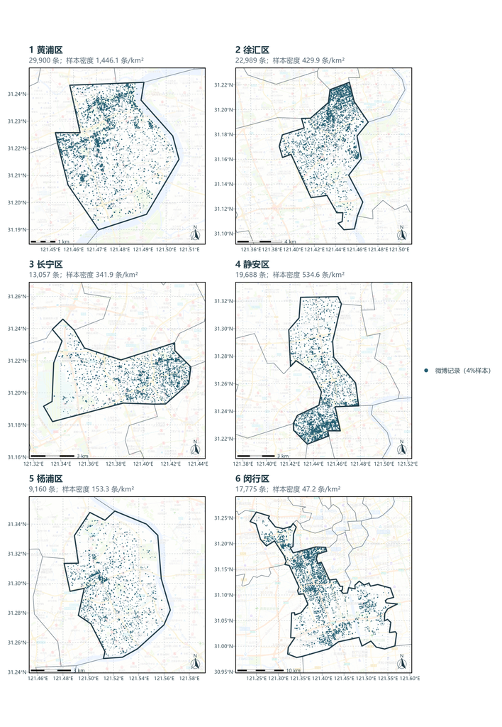

2020–2025年上海微博4%随机样本的区内原始点分布。编号与研究区总览一致；副标题密度为累计样本记录数除以区面积。各区独立缩放，面板比例尺不同。

**6 · 检查记录并按行政区筛选**

```r
# 模块 6 · 检查记录并按行政区筛选 ----------------------
# 使用 weibo_raw 与研究区边界；输出 weibo_study 及各步数量汇总。

# 1) 检查时间与坐标，并创建米制空间点。
# 先保留完整4%样本，再在分析阶段按明确规则筛选；不重新抽样或按区补齐数量。
weibo_clean <- weibo_raw %>%
  mutate(
    posted_at = as.POSIXct(
      posted_at,
      format = "%Y-%m-%d %H:%M:%S",
      tz = "Asia/Shanghai"
    )
  ) %>%
  filter(
    is.finite(longitude),
    is.finite(latitude),
    between(longitude, -180, 180),
    between(latitude, -90, 90),
    !is.na(posted_at),
    year %in% 2020:2025
  )
# 先声明原始经纬度的WGS84坐标系，再转换为米制投影；声明坐标系不会移动点。
weibo_points <- st_as_sf(
  weibo_clean,
  coords = c("longitude", "latitude"),
  crs = 4326,
  remove = FALSE
) %>%
  st_transform(target_crs)


# 2) 判断市内范围，再将记录唯一分配到研究区。
# 坐标合法不等于落在上海。行政边界判断另行进行，并记录范围外数量。
city_union <- st_union(shanghai_districts)
inside_city <- lengths(st_intersects(weibo_points, city_union)) > 0L
weibo_shanghai <- weibo_points[inside_city, ]
# st_intersects包含边界点；接触两区的记录按固定区序唯一归属，避免重复计数。
district_hits <- st_intersects(weibo_shanghai, study_districts)
district_index <- vapply(
  district_hits,
  function(hit) {
    if (length(hit)) hit[1] else NA_integer_
  },
  integer(1)
)

weibo_study <- weibo_shanghai[!is.na(district_index), ] %>%
  mutate(
    district_name = factor(
      district_order[district_index[!is.na(district_index)]],
      levels = district_order
    )
  )

# 3) 汇总每步记录数、各区面积与用户数，保存核查表。
quality_summary <- tibble(
  check = c(
    "4%样本", "时间坐标筛选后", "落在上海边界内",
    "六区研究记录", "接触多区边界的记录"
  ),
  n = c(
    nrow(weibo_raw),
    nrow(weibo_clean),
    nrow(weibo_shanghai),
    nrow(weibo_study),
    sum(lengths(district_hits) > 1L)
  )
)
district_summary <- study_districts %>%
  mutate(area_km2 = as.numeric(st_area(.)) / 1e6) %>%
  st_drop_geometry() %>%
  dplyr::select(district_name, district_code, area_km2) %>%
  left_join(
    st_drop_geometry(weibo_study) %>%
      group_by(district_name) %>%
      summarise(
        records = n(),
        users = n_distinct(user_id),
        .groups = "drop"
      ),
    by = "district_name"
  )

stopifnot(
  sum(district_summary$records) == nrow(weibo_study),
  all(district_summary$records > 0L)
)
write_csv(quality_summary, file.path(result_dir, "quality_summary.csv"))
write_csv(district_summary, file.path(result_dir, "district_summary.csv"))

# 地图说明单独保存，不往原统计表添加或覆盖字段。
# 分母为UTM下的行政区面积；分子只含2020—2025年4%随机样本中的有效记录。
# 这是累计样本记录密度，不乘25推算总体，也不当作人口密度或年均密度。
map_display_summary <- district_summary %>%
  mutate(
    district_id = match(as.character(district_name), district_order),
    sample_record_density_km2 = records / area_km2
  ) %>%
  dplyr::select(
    district_id, district_name, district_code, area_km2,
    records, sample_record_density_km2
  )

weibo_study %>%
  st_drop_geometry() %>%
  count(district_name, year, month) %>%
  write_csv(file.path(result_dir, "district_month_counts.csv"))
```

**7 · 绘制六区微博点分布**

```r
# 模块 7 · 绘制六区微博点分布 ----------------------
# 使用全部区内研究记录；各区沿用固定视野和编号。

# 逐区绘制全部研究点，再按统一顺序拼图；点的透明度只影响显示。
point_panels <- lapply(seq_along(district_order), function(i) {
  region_name <- district_order[i]
  points_i <- weibo_study %>% filter(district_name == region_name)
  map_base(
    region_name,
    i,
    paste0(
      format(nrow(points_i), big.mark = ","), " 条；样本密度 ",
      formatC(
        map_display_summary$sample_record_density_km2[i],
        format = "f", digits = 1, big.mark = ","
      ),
      " 条/km²"
    )
  ) +
    # aes()内的颜色映射生成图例；放大图例点不改变地图上的点大小。
    geom_sf(
      data = st_transform(points_i, display_crs),
      aes(colour = "微博记录（4%样本）"),
      alpha = 0.30,
      size = 0.16
    ) +
    scale_colour_manual(
      values = c("微博记录（4%样本）" = point_colour),
      name = NULL,
      guide = guide_legend(override.aes = list(size = 2.2, alpha = 1))
    ) +
    geom_sf(
      data = study_display[i, ],
      fill = NA,
      colour = "#253e49",
      linewidth = 0.90
    ) +
    map_references(region_name)
})
point_board <- (
  wrap_plots(point_panels, ncol = 2, guides = "collect")
) &
  theme(legend.position = "right", legend.margin = margin(0, 0, 0, 3))
export_board(point_board, "weibo-points-six-districts-2020-2025")
show_course_plot(point_board)
```

**读图与检查**

本次上海边界内有 215,403 条记录，其中六区共 112,569 条。各区数量与面积如下；用户数指样本内匿名代码数。

[output not shown]

**副标题中的密度怎样理解？** 这是2020–2025年上海微博4%随机样本的**累计记录数÷区面积**，单位为条/km²，描述区内平均数量强度。它不代表全部微博的记录密度，本例不据此推算总体记录数。下一节KDE进一步观察区内不同位置的局部变化。

**六区地图按两列三行、1–6编号排列**，可点击图片放大查看。所有地图真北朝上，经纬网横平竖直。**各面板比例尺不同**，同一区在点图、KDE和AOI图中保持相同视野。点重叠会掩盖记录数量，局部色深也受透明度影响，不能只凭点图的颜色深浅判断密度。

**© 华东师范大学 社会发展学院 人口研究所** | [**DAWN 研究组**](https://dawn-ecnu.github.io) | yzliu@soci.ecnu.edu.cn

课程负责人：刘贇喆 本章作者：刘贇喆 | 敖漪宇

最后更新：2026年10月20日 构建环境：R version 4.6.1 (2026-06-24 ucrt)

[CC BY-NC-SA 4.0](https://creativecommons.org/licenses/by-nc-sa/4.0/deed.zh) 回到顶部

##### 核密度估计

###### **4.4 核密度估计：从点到连续表面**

核密度估计（Kernel Density Estimation, KDE）在每个记录位置放置一个平滑核，叠加各点的贡献，用于描述记录在空间上的相对集中程度。

**本例按“区内点 → 自动带宽 KDE → AOI”逐区分析：**

- **输入记录**：每次只使用已经截取的本区微博点，不纳入邻区记录，也不设置区外缓冲区。
- **自动带宽**：按 `MASS::kde2d()` 的默认经验规则，由各区点坐标分别估计分析投影X、Y方向的带宽，大致对应东西、南北方向。实际平滑尺度因区而异，经验规则给出的结果仍需检查。
- **共同网格与单位**：统一使用75米网格；将概率密度乘以本区输入记录数，再换算为**样本记录/km²**。像元值表示平滑强度，不能当作该像元内的精确记录数。

地图采用**Inferno色带**，由低到高叠加等值面，密度透明度为0.1–0.8。色带与透明度只影响显示，AOI仍按原密度计算。

**跨区读图**：各区实际带宽和色标不同，相同颜色不能直接比较跨区强度。先看区内位置与形态，再结合各自的色条数值判断密度。

**带宽、网格与图面分层，分别控制什么？**

**带宽：平滑尺度**

由各区数据自动估计。较大时相邻高值区可能合并，较小时保留更多局部起伏；高斯核带宽不能直接当作步行服务半径。

**网格：评价位置**

本例网格边长为**75米**，决定在哪些位置计算密度及表面细度。增加网格数量，不能代替选择合适的带宽。

**分层：显示级数**

`bins = 20` 控制绘制多少级密度等值面。它只用于绘图，不参与自动带宽选择，也不决定AOI阈值。

**原理与延伸阅读：密度值、核函数与空间平滑**

对等权记录，二维 KDE 可写为：

$$\hat f(x,y)=\frac{1}{n h_x h_y}\sum_{i=1}^{n}
K\!\left(\frac{x-x_i}{h_x},\frac{y-y_i}{h_y}\right).$$

其中 $n$ 是记录数，$h_x$、$h_y$ 是分析投影X、Y方向的平滑尺度。高斯核的贡献随距离逐渐衰减。

`MASS::kde2d()` 返回概率密度估计。坐标以米表示时，概率密度单位为每平方米；本例再乘以记录数和 $10^6$，得到样本记录/km²。不同软件的核函数和带宽约定可能不同，参数值不能直接照搬。

本例只用区内点估计密度，再按区界裁剪，**未做边界质量补偿**。高斯核的一部分会延伸到区外，因此区内栅格的积分不必等于输入记录数。区界附近的估计也会受到未纳入邻区记录的影响。

- [ArcGIS Pro：How Kernel Density works](https://pro.arcgis.com/en/pro-app/latest/tool-reference/spatial-analyst/how-kernel-density-works.htm)：核函数叠加的图解；其具体实现与 R 函数需分别核对。
- [eks：Tidy spatial kernel density estimates](https://cran.r-project.org/web/packages/eks/vignettes/tidysf_kde.html)：带空间参考的 KDE 操作示例。

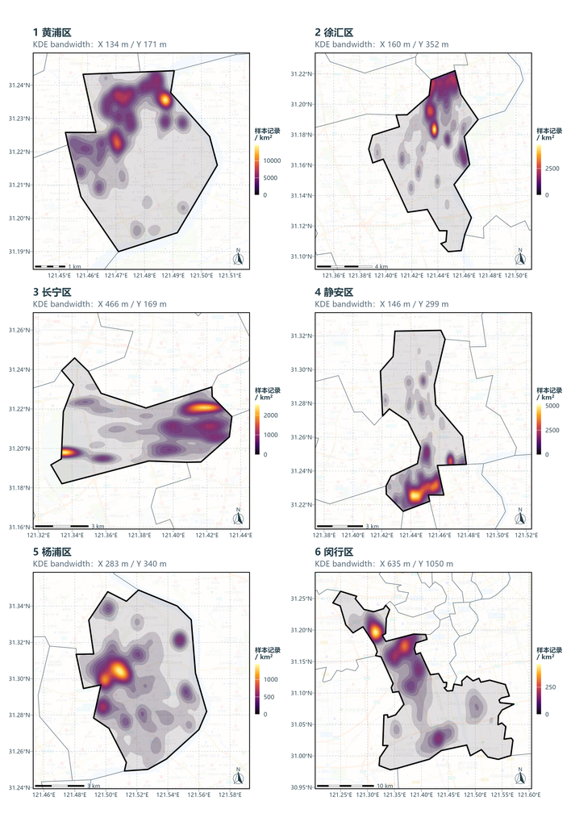

六区KDE：仅使用各区内记录，统一75米网格。副标题的KDE bandwidth列出分析投影X、Y方向的实际带宽，单位为米；各图区内自动带宽和色标不同。

**8 · 逐区估计带宽并计算 KDE**

```r
# 模块 8 · 逐区估计带宽并计算 KDE ----------------------
# 使用本区点与区界；输出 density_surfaces、带宽表与密度栅格。

# 每区只使用上一步裁取的本区记录，先自动估计带宽，再计算密度表面。
# 本例不增加区外缓冲记录；边界影响留在回顾与反思中讨论。
# 1) 定义单区计算：估计带宽 → 建评价网格 → 计算密度 → 按区界掩膜。
make_density_surface <- function(boundary, district_points) {
  xy <- st_coordinates(district_points)
  stopifnot(
    nrow(xy) > 1L,
    all(lengths(st_intersects(district_points, boundary)) > 0L)
  )

  # MASS默认分别按X、Y方向的数据离散程度与记录数估计带宽。
  # bandwidth.nrd含4倍约定；kde2d内部会除4，下面记录的是实际高斯尺度。
  auto_h <- c(
    MASS::bandwidth.nrd(xy[, 1]),
    MASS::bandwidth.nrd(xy[, 2])
  )
  stopifnot(all(is.finite(auto_h)), all(auto_h > 0))
  effective_h_m <- auto_h / 4

  box <- st_bbox(boundary)
  x_edges <- seq(
    floor(box["xmin"] / cell_m) * cell_m,
    ceiling(box["xmax"] / cell_m) * cell_m,
    by = cell_m
  )
  y_edges <- seq(
    floor(box["ymin"] / cell_m) * cell_m,
    ceiling(box["ymax"] / cell_m) * cell_m,
    by = cell_m
  )
  x_centres <- head(x_edges, -1) + cell_m / 2
  y_centres <- head(y_edges, -1) + cell_m / 2

  # 省略h，直接采用kde2d的自动带宽；n只控制评价网格数量。
  # 固定网格不等于固定带宽，各区的平滑尺度仍由本区记录估计。
  density_fit <- MASS::kde2d(
    xy[, 1],
    xy[, 2],
    n = c(length(x_centres), length(y_centres)),
    lims = c(range(x_centres), range(y_centres))
  )
  grid_data <- expand.grid(x = density_fit$x, y = density_fit$y)
  # kde2d返回概率密度。乘本区实际输入点数和1e6，转为“样本记录/km²”；
  # 这里不乘25推算总体，更不能解释为居民人数密度。
  grid_data$intensity <- as.vector(density_fit$z) * nrow(xy) * 1e6
  surface <- terra::rast(grid_data, type = "xyz", crs = "EPSG:32651")
  # xyz中的x/y是像元中心，避免把评价点误当成像元边界的半格偏移。
  # touches=FALSE按像元中心判断是否在区内，区外设置为NA而非0。
  surface <- terra::mask(surface, terra::vect(boundary), touches = FALSE)
  # 绘图保留完整矩形矩阵供色带插值，再将色带裁至区界。
  # 此处不把掩膜外NA补为0，也不增加区外输入点。
  density_field <- list(
    x = density_fit$x,
    y = density_fit$y,
    z = density_fit$z * nrow(xy) * 1e6
  )
  list(
    raster = surface,
    source_n = nrow(xy),
    hx_m = effective_h_m[1],
    hy_m = effective_h_m[2],
    field = density_field,
    grid = terra::as.data.frame(surface, xy = TRUE, na.rm = TRUE)
  )
}

# 2) 对六区分别调用函数；各区带宽取决于本区数据。
density_surfaces <- lapply(seq_along(district_order), function(i) {
  message("KDE: ", district_order[i])
  district_points <- weibo_study %>% filter(district_name == district_order[i])
  surface <- make_density_surface(study_districts[i, ], district_points)
  terra::writeRaster(
    surface$raster,
    file.path(result_dir, paste0("kde_", study_districts$district_code[i], ".tif")),
    overwrite = TRUE,
    datatype = "FLT4S",
    gdal = "COMPRESS=LZW"
  )
  surface
})
names(density_surfaces) <- district_order
# 3) 保存实际高斯核带宽及密度栅格，供读图和结果核对。
bandwidth_summary <- tibble(
  district_name = district_order,
  district_code = study_districts$district_code,
  records = vapply(density_surfaces, function(x) x$source_n, integer(1)),
  hx_m = vapply(density_surfaces, function(x) x$hx_m, numeric(1)),
  hy_m = vapply(density_surfaces, function(x) x$hy_m, numeric(1)),
  grid_m = cell_m
)
stopifnot(all(bandwidth_summary$records == district_summary$records))
write_csv(bandwidth_summary, file.path(result_dir, "bandwidth_summary.csv"))
map_display_summary <- map_display_summary %>%
  left_join(
    bandwidth_summary %>% dplyr::select(district_name, hx_m, hy_m, grid_m),
    by = "district_name"
  )
district_maxima <- vapply(
  density_surfaces,
  function(x) max(x$grid$intensity),
  numeric(1)
)
```

**9 · 绘制密度等值面**

```r
# 模块 9 · 绘制密度等值面 ----------------------
# 将上一步的密度表面转换为显示图层；不在绘图时重新估计密度。

# 只将上一步的KDE表面转成等值色带，不在绘图时重新估计密度。
make_density_bands <- function(density_field, boundary, bins = 20L) {
  if (!requireNamespace("isoband", quietly = TRUE) ||
      !requireNamespace("sf", quietly = TRUE)) {
    stop("绘制等值色带需要安装isoband和sf。")
  }
  if (length(bins) != 1L || !is.finite(bins) || bins < 1 ||
      bins != as.integer(bins)) {
    stop("bins必须是正整数。")
  }
  if (!inherits(boundary, "sf") || nrow(boundary) < 1L ||
      is.na(sf::st_crs(boundary)) || isTRUE(sf::st_is_longlat(boundary))) {
    stop("boundary须为具有米制投影坐标的非空sf区界。")
  }

  # 1) 检查矩阵方向、网格与区界，保持原始密度单位。
  x <- as.double(density_field$x)
  y <- as.double(density_field$y)
  z <- density_field$z
  if (length(x) < 2L || length(y) < 2L || !is.matrix(z) ||
      !identical(dim(z), c(length(x), length(y))) ||
      any(!is.finite(x)) || any(!is.finite(y)) ||
      any(diff(x) <= 0) || any(diff(y) <= 0) ||
      any(!is.finite(z)) || any(z < 0)) {
    stop("密度输入须为递增的x/y和完整、非负的z矩阵，维度为length(x)×length(y)。")
  }
  storage.mode(z) <- "double"
  boundary_geometry <- sf::st_make_valid(sf::st_geometry(boundary))
  boundary_geometry <- sf::st_union(boundary_geometry)
  crs <- sf::st_crs(boundary)
  empty_result <- function() {
    sf::st_sf(
      level_low = numeric(),
      level_high = numeric(),
      level_mid = numeric(),
      geometry = sf::st_sfc(crs = crs)
    )
  }
  display_max <- density_field$display_max
  if (is.null(display_max)) display_max <- max(z)
  if (length(display_max) != 1L || !is.finite(display_max) || display_max < 0) {
    stop("display_max须为区内有效格心密度的非负有限最大值。")
  }
  if (all(sf::st_is_empty(boundary_geometry)) || max(z) == 0 || display_max == 0) {
    return(empty_result())
  }

  # 2) 构造显示层级；嵌套面从低到高叠加透明度。
  # 等值面仅分级显示原密度值，不归一化、不补零，也不改变AOI阈值。
  # 优先使用区内格心最大值，避免区外高值决定本区的显示色阶。
  breaks <- seq(0, display_max, length.out = as.integer(bins) + 1L)
  level_low <- head(breaks, -1L)
  level_high <- tail(breaks, -1L)
  level_mid <- (level_low + level_high) / 2
  # 阈值以上的嵌套面从低到高绘制，并累积透明度。
  # 这些图层仍取自同一份原始密度，不改变AOI所用数值。
  level_high[] <- Inf
  # kde2d的z按[x,y]存储；isoband按[行y,列x]读取，必须转置。
  bands <- isoband::isobands(
    x = x,
    y = y,
    z = t(z),
    levels_low = level_low,
    levels_high = level_high
  )
  band_geometry <- sf::st_sfc(isoband::iso_to_sfg(bands), crs = crs)
  keep <- !sf::st_is_empty(band_geometry)
  if (!any(keep)) return(empty_result())
  band_data <- data.frame(
    level_low = level_low[keep],
    level_high = level_high[keep],
    level_mid = level_mid[keep]
  )
  band_geometry <- sf::st_make_valid(band_geometry[keep])

  # 3) 裁剪显示面，并移除空几何；不改分析栅格。
  # 先生成完整等值面，再严格裁至区界，避免NA掩膜造成边缘色带缺口。
  clipped <- sf::st_intersection(band_geometry, boundary_geometry)
  if (!length(clipped)) return(empty_result())
  source_index <- attr(clipped, "idx")[, 1L]
  result <- sf::st_sf(band_data[source_index, , drop = FALSE], geometry = clipped)
  result <- sf::st_make_valid(result)
  if (any(sf::st_geometry_type(result) == "GEOMETRYCOLLECTION")) {
    result <- sf::st_collection_extract(result, "POLYGON", warn = FALSE)
  }
  keep <- sf::st_geometry_type(result) %in% c("POLYGON", "MULTIPOLYGON") &
    !sf::st_is_empty(result)
  result <- result[keep, , drop = FALSE]
  if (!nrow(result)) return(empty_result())
  result <- result[order(result$level_low), , drop = FALSE]
  rownames(result) <- NULL
  result
}

# 定义色标并逐区出图：密度 alpha 随显示层级变化，底图 alpha 另行设置。
# 每区保留独立数值色标，便于查看本区结构。
# 相同颜色在不同区可对应不同强度，跨区比较须读取各自图例数值。
heat_scale <- function(maximum) {
  list(
    scale_fill_viridis_c(
      option = "inferno",
      limits = c(0, maximum),
      oob = scales::squish,
      name = "样本记录\n/ km²",
      breaks = scales::breaks_extended(n = 3),
      guide = guide_colourbar(
        barwidth = grid::unit(0.22, "cm"),
        barheight = grid::unit(2.5, "cm"),
        title.position = "top"
      )
    ),
    scale_alpha_continuous(
      range = c(0.1, 0.8),
      limits = c(0, maximum),
      oob = scales::squish,
      guide = "none"
    ),
    theme(
      legend.position = "right",
      legend.title = element_text(size = 9.0, face = "bold"),
      legend.text = element_text(size = 8.5),
      legend.margin = margin(0, 0, 0, 1)
    )
  )
}
density_bands <- lapply(seq_along(density_surfaces), function(i) {
  density_field <- density_surfaces[[i]]$field
  density_field$display_max <- district_maxima[i]
  make_density_bands(density_field, study_districts[i, ], bins = 20)
})
# 等值带仅在显示时重投影；原KDE数值、UTM评价点和AOI阈值均不重算。
density_bands_display <- lapply(density_bands, st_transform, crs = display_crs)
kde_panels <- lapply(seq_along(district_order), function(i) {
  region_name <- district_order[i]
  map_base(
    region_name,
    i,
    sprintf(
      "KDE bandwidth：X %.0f m / Y %.0f m",
      bandwidth_summary$hx_m[i],
      bandwidth_summary$hy_m[i]
    ),
    tile_alpha = 0.12
  ) +
    geom_sf(
      data = density_bands_display[[i]],
      aes(fill = level_mid, alpha = level_mid),
      colour = NA
    ) +
    heat_scale(district_maxima[i]) +
    geom_sf(
      data = study_display[i, ],
      fill = NA,
      colour = "black",
      linewidth = 0.90
    ) +
    map_references(region_name)
})
kde_board <- wrap_plots(kde_panels, ncol = 2, guides = "keep")
export_board(kde_board, "weibo-kde-six-districts-2020-2025")
show_course_plot(kde_board)
```

**本次自动带宽**：地图副标题与下表报告高斯核实际使用的X、Y方向带宽，单位为米。这两个方向属于UTM分析投影，与真北朝上的显示方向略有差别；默认经验规则不表示已经找到最优带宽。

| 研究区 | 记录数 | X方向带宽 m | Y方向带宽 m | 网格 m |
| --- | --- | --- | --- | --- |
| 黄浦区 | 29900 | 134.4 | 170.9 | 75 |
| 徐汇区 | 22989 | 159.9 | 352.0 | 75 |
| 长宁区 | 13057 | 466.2 | 168.8 | 75 |
| 静安区 | 19688 | 146.1 | 298.8 | 75 |
| 杨浦区 | 9160 | 282.7 | 339.9 | 75 |
| 闵行区 | 17775 | 635.3 | 1049.6 | 75 |

**这张密度图怎么读？**

先查看各区高值部分的位置和连片情况，再结合本区带宽及图例读取密度。较小带宽通常保留更多局部起伏，较大带宽可能连接邻近高值区；跨区形态差异也会受到平滑尺度的影响。地图汇总2020–2025年的记录，高值区的活动类型与持续性仍需进一步核对。

**接下来的任务**是为高值区域建立可重复的分析边界，以便比较区域内外的记录位置。该边界由数据与参数共同决定。

**下方为模拟点平滑演示**：画布坐标与带宽使用像素，颜色来自未归一化的核叠加值，用于观察平滑形态。它不使用本例的真实微博数据，滑块数值不能直接套入 R 的空间分析。

[interactive chart not shown]

**© 华东师范大学 社会发展学院 人口研究所** | [**DAWN 研究组**](https://dawn-ecnu.github.io) | yzliu@soci.ecnu.edu.cn

课程负责人：刘贇喆 本章作者：刘贇喆 | 敖漪宇

最后更新：2026年10月20日 构建环境：R version 4.6.1 (2026-06-24 ucrt)

[CC BY-NC-SA 4.0](https://creativecommons.org/licenses/by-nc-sa/4.0/deed.zh) 回到顶部

##### 边界提取与可视化

###### **4.5 高密度区提取与 AOI 边界**

本节从**刚才计算的同一份KDE表面**提取高值分析区，称为 **AOI**（Area of Interest）。绘图时不再重新估计另一份密度。

1. **限定评价范围**：只使用像元中心落在相应区内的有效网格。
2. **逐区取阈值**：分别计算每个区内密度的第95百分位数，提取达到该阈值的高值网格。
3. **转面并裁剪**：合并相邻高值网格，与区界相交，得到可用于记录分组的多边形。
4. **统计连通部分**：共享边或顶点、可以彼此连通的AOI合计为1个；面积按UTM投影计算所有AOI的合计面积。
5. **叠加核对**：AOI边界叠在原KDE上，检查位置、范围与边界是否对应。

**Top 5% 是区内排名，六区的绝对阈值不同。** 边界网格裁剪、密度并列等情况会使AOI面积不恰好等于区面积的5%。AOI随数据与参数变化，不代表固定城市功能区，也不等同于统计显著热点。

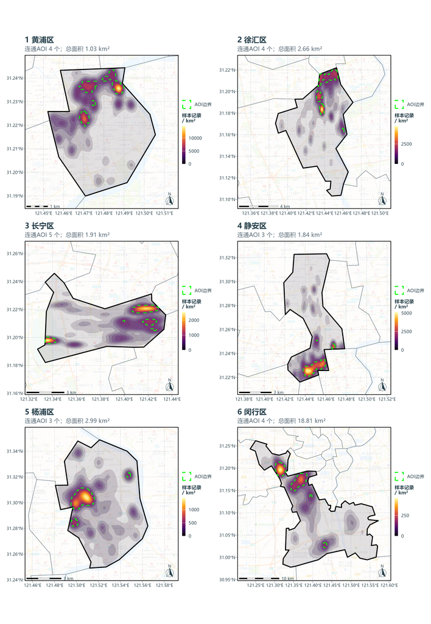

同一KDE表面上提取的AOI。绿色虚线表示各区内密度排名前5%的高值分析区；副标题列出连通AOI个数及合计面积，共享边或顶点的区域计为同一个。各图色标不同。

**10 · 提取 AOI 并统计连通区域**

```r
# 模块 10 · 提取 AOI 并统计连通区域 ----------------------
# 使用同一份密度表面与区内阈值；输出 aoi_regions 及记录分组。

# 阈值在各区的有效网格内分别计算，不能把六区合在一起取95%分位。
# 各区的绝对阈值不同，所得AOI用于区内高值区/其余地区的分组。
# 1) 逐区阈值化、转为多边形，再严格裁至本区边界。
aoi_list <- lapply(seq_along(district_order), function(i) {
  surface <- density_surfaces[[i]]$raster
  threshold <- unname(quantile(density_surfaces[[i]]$grid$intensity, aoi_quantile))
  high_cells <- terra::ifel(surface >= threshold, 1, NA)
  high_polygons <- terra::as.polygons(
    high_cells,
    dissolve = TRUE,
    na.rm = TRUE
  ) %>%
    st_as_sf() %>%
    st_make_valid()
  # 网格面还需与区界相交；边界格被裁切后，面积不保证恰好占全区5%。
  clipped <- st_intersection(
    st_geometry(high_polygons),
    st_geometry(study_districts[i, ])
  )
  st_sf(
    district_name = district_order[i],
    threshold = threshold,
    geometry = st_union(clipped)
  )
})
aoi_regions <- do.call(rbind, aoi_list)
stopifnot(all(st_is_valid(aoi_regions)), !any(st_is_empty(aoi_regions)))
st_write(
  st_transform(aoi_regions, 4326),
  file.path(result_dir, "aoi_six_districts.geojson"),
  delete_dsn = TRUE,
  quiet = TRUE
)

# 2) 将原始记录分为 AOI 内外，并汇总面积与记录覆盖率。
# 区内样本按自身所在区的AOI分类，不用其他区的AOI给本区记录分组。
aoi_hits <- st_intersects(weibo_study, aoi_regions)
own_aoi_index <- match(as.character(weibo_study$district_name), aoi_regions$district_name)
aoi_inside <- mapply(
  function(hit, own_index) own_index %in% hit,
  aoi_hits,
  own_aoi_index,
  USE.NAMES = FALSE
)
weibo_study$aoi_group <- factor(
  ifelse(aoi_inside, "AOI 内", "AOI 外"),
  levels = c("AOI 内", "AOI 外")
)
aoi_summary <- district_summary %>%
  left_join(st_drop_geometry(aoi_regions), by = "district_name") %>%
  mutate(
    aoi_km2 = as.numeric(st_area(aoi_regions)) / 1e6,
    aoi_area_percent = 100 * aoi_km2 / area_km2
  ) %>%
  left_join(
    st_drop_geometry(weibo_study) %>%
      group_by(district_name) %>%
      summarise(
        aoi_records = sum(aoi_group == "AOI 内"),
        aoi_record_percent = 100 * mean(aoi_group == "AOI 内"),
        .groups = "drop"
      ),
    by = "district_name"
  )
write_csv(aoi_summary, file.path(result_dir, "aoi_summary.csv"))

# 3) 统计连通区域；共边或共点都算相连。
# AOI个数按平面几何的连通分量计算，不能直接读取sf行数。
# 先将完整面拆为polygon片，再按st_intersects建立相邻关系：
# 共享边或仅共享一个点都算相连；孔洞不单独计数，也不加入距离容差。
# 以下只生成地图说明指标，不改变AOI几何或记录的内外分组。
count_aoi_components <- function(aoi_geometry) {
  polygon_geometry <- st_make_valid(st_geometry(aoi_geometry))
  if (any(st_geometry_type(polygon_geometry) == "GEOMETRYCOLLECTION")) {
    polygon_geometry <- st_collection_extract(
      polygon_geometry, "POLYGON", warn = FALSE
    )
  }
  polygon_parts <- polygon_geometry %>%
    st_union() %>%
    st_cast("POLYGON", warn = FALSE)
  polygon_parts <- polygon_parts[!st_is_empty(polygon_parts)]
  if (!length(polygon_parts)) return(0L)

  neighbours <- st_intersects(polygon_parts)
  visited <- rep(FALSE, length(polygon_parts))
  component_count <- 0L
  for (start in seq_along(polygon_parts)) {
    if (visited[start]) next
    component_count <- component_count + 1L
    pending <- start
    visited[start] <- TRUE
    while (length(pending)) {
      current <- pending[1L]
      pending <- pending[-1L]
      new_parts <- neighbours[[current]][!visited[neighbours[[current]]]]
      visited[new_parts] <- TRUE
      pending <- c(pending, new_parts)
    }
  }
  component_count
}

aoi_map_metrics <- aoi_summary %>%
  dplyr::select(district_name, aoi_km2) %>%
  mutate(
    aoi_connected_components = vapply(
      seq_len(nrow(aoi_regions)),
      function(i) count_aoi_components(aoi_regions[i, ]),
      integer(1)
    )
  )
map_display_summary <- map_display_summary %>%
  left_join(aoi_map_metrics, by = "district_name")
stopifnot(
  identical(map_display_summary$district_id, seq_along(district_order)),
  all(map_display_summary$aoi_connected_components > 0L),
  all(is.finite(map_display_summary$sample_record_density_km2))
)
write_csv(map_display_summary, file.path(result_dir, "map_display_summary.csv"))
```

**11 · 叠加 AOI 与密度表面**

```r
# 模块 11 · 叠加 AOI 与密度表面 ----------------------
# 使用已提取的 AOI；显示投影转换不改变面积与内外分组。

# AOI与KDE色带使用同一显示投影；分析对象aoi_regions继续保留UTM坐标。
aoi_display <- st_transform(aoi_regions, display_crs)
aoi_panels <- lapply(seq_along(district_order), function(i) {
  region_name <- district_order[i]
  map_base(
    region_name,
    i,
    paste0(
      "连通AOI ", map_display_summary$aoi_connected_components[i], " 个；总面积 ",
      format(round(aoi_summary$aoi_km2[i], 2), nsmall = 2),
      " km²"
    ),
    tile_alpha = 0.16
  ) +
    geom_sf(
      data = density_bands_display[[i]],
      aes(fill = level_mid, alpha = level_mid),
      colour = NA
    ) +
    heat_scale(district_maxima[i]) +
    geom_sf(
      data = study_display[i, ],
      fill = NA,
      colour = "black",
      linewidth = 0.90
    ) +
    geom_sf(
      data = aoi_display[i, ],
      aes(colour = "AOI 边界"),
      fill = NA,
      linewidth = 0.75,
      linetype = "dashed"
    ) +
    scale_colour_manual(
      values = c("AOI 边界" = aoi_colour),
      labels = c("AOI 边界" = "AOI边界"),
      name = NULL,
      guide = guide_legend(
        order = 2,
        override.aes = list(linewidth = 0.8, alpha = 1)
      )
    ) +
    map_references(region_name)
})
# 色条与AOI线型均放在各面板右侧；独立色标不合并，避免混淆各区强度。
aoi_board <- wrap_plots(aoi_panels, ncol = 2, guides = "keep")
export_board(aoi_board, "weibo-aoi-six-districts-2020-2025")
show_course_plot(aoi_board)
```

**提取后检查什么？**

- AOI 是否与密度表面的高值部分对应？边界附近是否超出研究范围？
- 连片与分散部分各在哪里？改变阈值后，面积、数量和连通性如何变化？
- 每组包含多少记录？是否由少数用户、重复位置或短期事件主导？

下表列出本次AOI的连通个数、阈值、合计面积和记录覆盖比例，便于对照地图检查。**连通个数不等于独立功能区或活动中心的数量**，它会受到网格、带宽和阈值影响。记录覆盖比例指样本记录的位置落在AOI内的比例，不能解释为人口比例。

| 研究区 | 连通AOI数 | 密度阈值 记录/km² | AOI合计 km² | 面积占比 % | 记录覆盖 % |
| --- | --- | --- | --- | --- | --- |
| 黄浦区 | 4 | 5012.6 | 1.03 | 5.01 | 34.02 |
| 徐汇区 | 4 | 1775.9 | 2.66 | 4.98 | 37.89 |
| 长宁区 | 5 | 937.3 | 1.91 | 5.00 | 32.27 |
| 静安区 | 3 | 2240.3 | 1.84 | 5.00 | 39.58 |
| 杨浦区 | 3 | 486.0 | 2.99 | 5.00 | 36.24 |
| 闵行区 | 4 | 163.1 | 18.81 | 5.00 | 38.34 |

AOI内外分组建立后，下一步比较各记录位置到最近交通设施的距离。

**© 华东师范大学 社会发展学院 人口研究所** | [**DAWN 研究组**](https://dawn-ecnu.github.io) | yzliu@soci.ecnu.edu.cn

课程负责人：刘贇喆 本章作者：刘贇喆 | 敖漪宇

最后更新：2026年10月20日 构建环境：R version 4.6.1 (2026-06-24 ucrt)

[CC BY-NC-SA 4.0](https://creativecommons.org/licenses/by-nc-sa/4.0/deed.zh) 回到顶部